# Ayanambakkam et al. — ctDNA in UTUC: Clinical Analysis (BJUI revision)

George Laliotis, MD

2026-11-10

# 0. Purpose of the document and initial set-up

- **Scripts** — Clinical analysis of tumor-informed ctDNA (Signatera) in stage I–III UTUC (Ayanambakkam et al., *BJU International*, revision).
- **Output** — Figures and tables for the revised manuscript (Sections 1–8) and the supplementary analyses cited in the response to reviewers (Section 9).
- **Data** — The six `_NEW RULES` files in `~/Downloads` (five `.csv` files and `CLIA UTUC Time dependent data_NEWRULES.xlsx`). Edit `data_dir` or the file names in the `config` chunk if they differ.

```r
# **Loading necessary packages**
suppressPackageStartupMessages({
  library(tidyverse)
  library(readxl)
  library(lubridate)
  library(survival)
  library(survminer)
  library(coxphf)
  library(swimplot)
  library(gtsummary)
  library(flextable)
  library(DT)
  library(scales)
  library(htmltools)
  library(gt)          # publication tables; install.packages("gt") if needed
})
```

```r
# **Paths to the local files in ~/Downloads and output folder**
data_dir <- "~/Downloads"
out_dir  <- file.path(data_dir, "UTUC_BJUI_revision_outputs")
dir.create(out_dir, showWarnings = FALSE, recursive = TRUE)

files <- list(
  clin = "RWE UTUC_Clinical Data_NEW RULES.csv",
  op   = "RWE UTUC_OP 062026 MS NEW RULES.csv",
  mtm  = "CLIA UTUC ctDNA MTM_NEW RULES.csv",
  vel  = "CLIA UTUC ctDNA Velocity_NEW RULES.csv",
  td   = "CLIA UTUC Time dependent data_NEWRULES.xlsx",
  lt   = "CLIA UTUC_Lead Time pts_062025 NEW RULES.csv"
)
missing <- unlist(files)[!file.exists(file.path(data_dir, unlist(files)))]
if (length(missing) > 0) stop("Not found in ", data_dir, ": ", paste(missing, collapse = "; "))

DAYS_PER_MONTH <- 30.437
```

```r
# **Helper functions (type conversion, formatting, plotting)**
na_strings <- c("", "NA", "N/A", "#VALUE!", "NaN")

# Reads a .csv or .xlsx from data_dir as all-text columns; duplicated headers get a "_dup" suffix
read_tab <- function(key) {
  path <- file.path(data_dir, files[[key]])
  repair <- function(x) make.unique(x, sep = "_dup")
  raw <- if (grepl("\\.xlsx?$", path, ignore.case = TRUE)) {
    read_excel(path, sheet = 1, col_types = "text", .name_repair = repair)
  } else {
    read_csv(path, col_types = cols(.default = col_character()), na = character(),
             name_repair = repair, show_col_types = FALSE, locale = locale(encoding = "UTF-8"))
  }
  raw |>
    mutate(across(everything(), ~ ifelse(trimws(.x) %in% na_strings, NA_character_, trimws(.x)))) |>
    as.data.frame()
}
to_num <- function(x) suppressWarnings(as.numeric(x))
to_lgl <- function(x) toupper(trimws(as.character(x))) %in% c("TRUE", "1", "YES")

# Handles Excel serials (e.g. 43523), m/d/Y, m/d/y and Y-m-d strings
parse_date_any <- function(x) {
  x   <- trimws(as.character(x))
  out <- as.Date(rep(NA_character_, length(x)))
  is_serial <- !is.na(x) & grepl("^\\d{5}(\\.\\d+)?$", x)
  out[is_serial] <- as.Date(floor(as.numeric(x[is_serial])), origin = "1899-12-30")
  rest <- !is_serial & !is.na(x)
  out[rest] <- as.Date(suppressWarnings(parse_date_time(x[rest], orders = c("mdY", "mdy", "Ymd"))))
  out
}

fmt_p  <- function(p) ifelse(is.na(p), "NA", ifelse(p < 0.001, "< 0.001", sprintf("= %.3f", p)))
fmt_hr <- function(hr, lo, hi, p) sprintf("HR = %.2f (95%% CI %.2f–%.2f); P %s", hr, lo, hi, fmt_p(p))

cox_tidy <- function(fit, label = NULL) {
  s <- summary(fit)
  tibble(term = rownames(s$conf.int), HR = s$conf.int[, 1], lower = s$conf.int[, 3],
         upper = s$conf.int[, 4], p = s$coefficients[, "Pr(>|z|)"],
         method = "Cox PH (Wald CI)", n = fit$n, events = fit$nevent, model = label)
}
firth_tidy <- function(fit, label = NULL) {
  tibble(term = names(fit$coefficients), HR = exp(fit$coefficients),
         lower = fit$ci.lower, upper = fit$ci.upper, p = fit$prob,
         method = "Firth penalized Cox (profile-likelihood CI)", model = label)
}
show_tbl <- function(df, caption = NULL, digits = 3) {
  df <- df |> mutate(across(where(is.double), ~ round(.x, digits)))
  datatable(df, caption = caption, rownames = FALSE, filter = "top",
            extensions = "Buttons",
            options = list(dom = "Bfrtip", buttons = c("copy", "csv", "excel"),
                           pageLength = 25, scrollX = TRUE))
}

pal_ctdna <- c("#1F4E9C", "#C0392B")          # Negative, Positive
theme_utuc <- function(base = 12) {
  theme_bw(base_size = base) +
    theme(panel.grid.minor = element_blank(),
          panel.grid.major = element_line(colour = "grey90", linewidth = 0.3),
          plot.title = element_text(face = "bold"),
          legend.position = "bottom")
}
save_fig <- function(p, name, w = 10, h = 7) {
  ggsave(file.path(out_dir, paste0(name, ".pdf")), p, width = w, height = h)
  ggsave(file.path(out_dir, paste0(name, ".png")), p, width = w, height = h, dpi = 300)
}

# Standard KM + Cox + Firth + Fisher bundle. d must have: time (months), event (0/1), group (factor)
km_bundle <- function(d, title, xlab, break_by, times, legend = c("ctDNA Negative", "ctDNA Positive")) {
  keep <- complete.cases(d[, c("time", "event", "group")]) & d$time > 0
  if (any(!keep)) {
    warning("km_bundle: dropped ", sum(!keep), " row(s) with missing or non-positive time: ",
            paste(d$Patient.ID[!keep], collapse = ", "))
    d <- d[keep, , drop = FALSE]
  }
  d <- as.data.frame(d)
  d$group <- droplevels(d$group)
  fit_km <- survfit(Surv(time, event) ~ group, data = d, conf.type = "log-log")   # log-log CIs as in the manuscript
  km <- ggsurvplot(fit_km, data = d, pval = FALSE, conf.int = FALSE, risk.table = TRUE,
                   break.time.by = break_by, palette = pal_ctdna, title = title,
                   ylab = "Recurrence-Free Survival", xlab = xlab,
                   legend.labs = legend, legend.title = "", ggtheme = theme_utuc(),
                   risk.table.height = 0.25)
  cox   <- coxph(Surv(time, event) ~ group, data = d)
  firth <- coxphf(Surv(time, event) ~ group, data = d)
  tab   <- table(d$group, factor(d$event, levels = c(0, 1), labels = c("No Recurrence", "Recurrence")))
  list(km = km, fit_km = fit_km,
       km_times = summary(fit_km, times = times, extend = TRUE),
       cox = cox, firth = firth,
       hr = bind_rows(cox_tidy(cox), firth_tidy(firth)),
       zph = cox.zph(cox), table = tab, fisher = fisher.test(tab),
       events = d |> group_by(group) |>
         summarise(Total = n(), Events = sum(event), `Event rate (%)` = round(100 * mean(event), 1), .groups = "drop"))
}

stacked_bar <- function(tab, title) {
  df <- as.data.frame(tab) |> group_by(Var1) |> mutate(Pct = Freq / sum(Freq)) |> ungroup()
  ft <- fisher.test(tab)
  ggplot(df, aes(Var1, Pct, fill = Var2)) +
    geom_col(width = 0.65, colour = "white") +
    geom_text(aes(label = Freq), position = position_stack(vjust = 0.5), size = 6, colour = "white", fontface = "bold") +
    scale_y_continuous(labels = percent_format()) +
    scale_fill_manual(values = c("No Recurrence" = pal_ctdna[1], "Recurrence" = pal_ctdna[2])) +
    labs(title = title, x = "ctDNA", y = "Patients (%)", fill = NULL,
         caption = paste0("Fisher's exact test P ", fmt_p(ft$p.value))) +
    theme_utuc(14)
}

forest_plot <- function(tbl, title) {
  tbl <- tbl |> mutate(label = factor(label, levels = rev(unique(label))))
  ggplot(tbl, aes(x = HR, y = label)) +
    geom_vline(xintercept = 1, linetype = "dashed", colour = "grey40") +
    geom_linerange(aes(xmin = lower, xmax = upper), linewidth = 0.8) +
    geom_point(shape = 15, size = 3.5, colour = pal_ctdna[2]) +
    geom_text(aes(label = sprintf("%.2f (%.2f–%.2f)", HR, lower, upper)),
              x = log10(max(tbl$upper, na.rm = TRUE) * 6), hjust = 1, size = 3.3) +
    scale_x_log10(expand = expansion(mult = c(0.05, 0.6))) +
    labs(title = title, x = "Hazard ratio (log scale)", y = NULL) +
    theme_utuc()
}
```

```r
# **Load and type the NEW RULES tabs**
clin <- read_tab("clin") |>
  mutate(across(c(Age, RFS, RFS.months, OS.months, ctDNA.timing, Nsurvtps), to_num),
         across(c(Short.cohort, Final.cohort, NAC, ACT, RFS.Event, OS.Event), to_lgl),
         across(c(Surgery.Date, RFS.Date, OS.Date, LastFU), parse_date_any),
         Stage  = factor(Stage,  levels = c("0/I", "II", "III")),
         cStage = factor(cStage, levels = c("0/I", "II/III")))

cohort <- clin |> filter(Final.cohort)          # n = 39 final clinical-performance cohort

op <- read_tab("op") |>
  mutate(across(c(Short.cohort, Final.cohort, RFS.Event), to_lgl),
         across(c(fu.diff.months, Tx_start, Tx_end, Tx_start.months, Tx_end.months,
                  date.diff, date.diff.months, MTM.mL), to_num),
         Event = ifelse(tolower(Event) == "death", "Death", Event),
         ctDNA.Window = case_when(tolower(ctDNA.Window) == "on-treatment" ~ "On-treatment",
                                  TRUE ~ ctDNA.Window),
         is_ct = Event_type %in% c("ctDNA_pos", "ctDNA_neg") & !is.na(date.diff)) |>
  filter(PatientName %in% cohort$Patient.ID)   # NB: filtering on Final.cohort would pull in a stray UTUC-057 row

mtm <- read_tab("mtm") |>
  mutate(across(c(Final.cohort, RFS.Event), to_lgl),
         across(c(date.diff, date.diff.months, MTM.mL), to_num)) |>
  filter(PatientName %in% cohort$Patient.ID)

vel <- read_tab("vel") |>
  mutate(across(c(Final.cohort, RFS.Event), to_lgl),
         across(c(date.diff, date.diff.months, MTM.mL, daysCR, daysCR.months), to_num)) |>
  filter(PatientName %in% cohort$Patient.ID)

lt <- read_tab("lt") |>
  mutate(Final.cohort = to_lgl(Final.cohort), across(c(MR, CR, LT, LT.months), to_num)) |>
  filter(Final.cohort)

td_raw <- read_tab("td")
# The local .xlsx may label the ID column differently (e.g. "Pts.ID"); standardise to Patient.ID
if (!"Patient.ID" %in% names(td_raw)) {
  id_col <- grep("^(pts|patient|pt)[._ ]?id$", names(td_raw), ignore.case = TRUE, value = TRUE)[1]
  if (is.na(id_col)) id_col <- names(td_raw)[1]
  names(td_raw)[names(td_raw) == id_col] <- "Patient.ID"
}

cat("Final cohort:", nrow(cohort), "patients |", nrow(op), "OP rows |",
    sum(op$is_ct), "plasma samples in OP tab\n")
```

```
## Final cohort: 39 patients | 437 OP rows | 265 plasma samples in OP tab
```

```r
# **Cohort checks (warnings only; the knit does not stop)**
expect <- function(label, observed, expected) {
  ok <- identical(as.integer(observed), as.integer(expected))
  if (!ok) warning(label, ": observed ", observed, ", expected ", expected)
  tibble(Check = label, Observed = observed, Expected = expected, OK = ok)
}
bind_rows(
  expect("Final cohort (patients)", nrow(cohort), 39),
  expect("MRD window: patients", sum(!is.na(cohort$ctDNA.MRD)), 28),
  expect("MRD window: positive", sum(cohort$ctDNA.MRD == "POSITIVE", na.rm = TRUE), 14),
  expect("MRD window: missing ctDNA.timing", sum(!is.na(cohort$ctDNA.MRD) & is.na(cohort$ctDNA.timing)), 0),
  expect("Surveillance window: patients", sum(!is.na(cohort$ctDNA.Surveillance)), 31),
  expect("Surveillance window: positive", sum(cohort$ctDNA.Surveillance == "POSITIVE", na.rm = TRUE), 16),
  expect("Recurrences (final cohort)", sum(cohort$RFS.Event), 19)
) |> show_tbl("Cohort checks against the counts used in the manuscript and rebuttal")
```

| Check | Observed | Expected | OK |
| --- | --- | --- | --- |
| Final cohort (patients) | 39 | 39 | True |
| MRD window: patients | 28 | 28 | True |
| MRD window: positive | 14 | 14 | True |
| MRD window: missing ctDNA.timing | 0 | 0 | True |
| Surveillance window: patients | 31 | 31 | True |
| Surveillance window: positive | 16 | 16 | True |
| Recurrences (final cohort) | 19 | 19 | True |

# 1. Figure 1 and Table 1

- **Detection rates** — ctDNA detection by window (early post-operative MRD, post-definitive surveillance, any time) and by stage.
- **Demographics** — Table 1 and a supplementary table by surveillance ctDNA status.

```r
# **ctDNA Detection Rates by Window and Stage**
detection_by_stage <- function(df, col) {
  d <- df |> filter(!is.na(.data[[col]]))
  bind_rows(
    d |> group_by(Stage) |> summarise(Total = n(), Positive = sum(.data[[col]] == "POSITIVE"), .groups = "drop") |>
      mutate(Stage = as.character(Stage)),
    d |> summarise(Stage = "Overall", Total = n(), Positive = sum(.data[[col]] == "POSITIVE"))
  ) |> mutate(`Rate (%)` = round(100 * Positive / Total, 2), Window = col, .before = 1)
}
det <- bind_rows(detection_by_stage(cohort, "ctDNA.MRD"),
                 detection_by_stage(cohort, "ctDNA.Surveillance"),
                 detection_by_stage(cohort, "ctDNA.anytime"))
show_tbl(det, "ctDNA detection by window and stage (final cohort)")
```

| Rate (%) | Window | Stage | Total | Positive |
| --- | --- | --- | --- | --- |
| 33.33 | ctDNA.MRD | 0/I | 6 | 2 |
| 50 | ctDNA.MRD | II | 6 | 3 |
| 56.25 | ctDNA.MRD | III | 16 | 9 |
| 50 | ctDNA.MRD | Overall | 28 | 14 |
| 42.86 | ctDNA.Surveillance | 0/I | 7 | 3 |
| 71.43 | ctDNA.Surveillance | II | 7 | 5 |
| 47.06 | ctDNA.Surveillance | III | 17 | 8 |
| 51.61 | ctDNA.Surveillance | Overall | 31 | 16 |
| 42.86 | ctDNA.anytime | 0/I | 7 | 3 |
| 62.5 | ctDNA.anytime | II | 8 | 5 |

[output cut: 2 more lines]

```r
# **Table 1 — Patient and tumor characteristics**
t1_data <- cohort |>
  transmute(Age, Sex = factor(Sex), `Clinical stage` = Stage,
            `Neoadjuvant treatment` = factor(NAC, c(FALSE, TRUE), c("No", "Yes")),
            `Adjuvant treatment`    = factor(ACT, c(FALSE, TRUE), c("No", "Yes")),
            `Adjuvant regimen`      = factor(ACT.type),
            Recurrence = factor(RFS.Event, c(FALSE, TRUE), c("No Recurrence", "Recurrence")),
            `Living status` = factor(OS.Event, c(FALSE, TRUE), c("Alive", "Deceased")),
            `Total follow-up (mo)` = OS.months)

table1 <- t1_data |>
  tbl_summary(statistic = list(all_continuous() ~ "{median} ({min} - {max})",
                               all_categorical() ~ "{n} ({p}%)"),
              missing = "no") |>
  bold_labels()
table1
```

| **Characteristic** | **N = 39**<sup>1</sup> |
| --- | --- |
| Age | 77 (47 - 92) |
| Sex |  |
| Female | 15 (38%) |
| Male | 24 (62%) |
| Clinical stage |  |
| 0/I | 7 (18%) |
| II | 8 (21%) |
| III | 24 (62%) |
| Neoadjuvant treatment | 6 (15%) |
| Adjuvant treatment | 26 (67%) |
| Adjuvant regimen |  |
| Chemotherapy | 11 (42%) |
| Immunotherapy | 15 (58%) |
| Recurrence |  |
| No Recurrence | 20 (51%) |
| Recurrence | 19 (49%) |
| Living status |  |
| Alive | 34 (87%) |
| Deceased | 5 (13%) |
| Total follow-up (mo) | 21 (3 - 45) |

<sup>1</sup> Median (Min - Max); n (%)

```r
save_as_docx(as_flex_table(table1), path = file.path(out_dir, "Table1_Demographics_UTUC.docx"))
```

```r
# **Supplementary — Characteristics by ctDNA status in the post-definitive surveillance window**
t1b <- cohort |> filter(!is.na(ctDNA.Surveillance)) |>
  transmute(Age, Sex = factor(Sex), `Clinical stage` = Stage,
            `Neoadjuvant treatment` = factor(NAC, c(FALSE, TRUE), c("No", "Yes")),
            `Adjuvant treatment`    = factor(ACT, c(FALSE, TRUE), c("No", "Yes")),
            Recurrence = factor(RFS.Event, c(FALSE, TRUE), c("No Recurrence", "Recurrence")),
            ctDNA = factor(ctDNA.Surveillance, c("NEGATIVE", "POSITIVE"), c("ctDNA Negative", "ctDNA Positive"))) |>
  tbl_summary(by = ctDNA, statistic = list(all_continuous() ~ "{median} ({min} - {max})",
                                           all_categorical() ~ "{n} ({p}%)"), missing = "no") |>
  add_overall() |> add_p() |> bold_labels()
t1b
```

| **Characteristic** | **Overall** N = 31<sup>1</sup> | **ctDNA Negative** N = 15<sup>1</sup> | **ctDNA Positive** N = 16<sup>1</sup> | **p-value**<sup>2</sup> |
| --- | --- | --- | --- | --- |
| Age | 77 (53 - 92) | 74 (53 - 92) | 81 (64 - 92) | 0.13 |
| Sex |  |  |  | 0.9 |
| Female | 14 (45%) | 7 (47%) | 7 (44%) |  |
| Male | 17 (55%) | 8 (53%) | 9 (56%) |  |
| Clinical stage |  |  |  | 0.6 |
| 0/I | 7 (23%) | 4 (27%) | 3 (19%) |  |
| II | 7 (23%) | 2 (13%) | 5 (31%) |  |
| III | 17 (55%) | 9 (60%) | 8 (50%) |  |
| Neoadjuvant treatment | 4 (13%) | 1 (6.7%) | 3 (19%) | 0.6 |
| Adjuvant treatment | 19 (61%) | 7 (47%) | 12 (75%) | 0.11 |
| Recurrence |  |  |  | <0.001 |
| No Recurrence | 17 (55%) | 14 (93%) | 3 (19%) |  |
| Recurrence | 14 (45%) | 1 (6.7%) | 13 (81%) |  |

<sup>1</sup> Median (Min - Max); n (%)  
<sup>2</sup> Wilcoxon rank sum exact test; Pearson’s Chi-squared test; Fisher’s exact test

```r
save_as_docx(as_flex_table(t1b), path = file.path(out_dir, "TableS_Demographics_by_ctDNA_Surveillance.docx"))
```

# 2. Figure 1B — Overview plot

Treatment, longitudinal ctDNA results, imaging and outcome for all 39 patients, stratified by clinical stage.

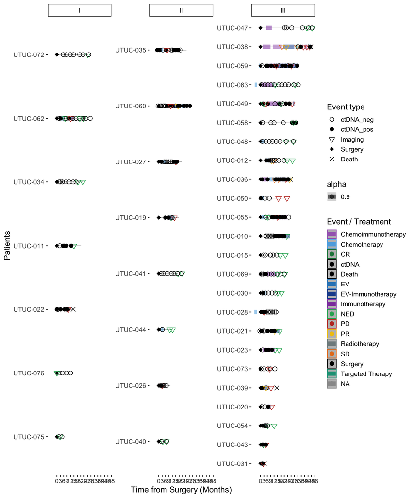

```r
# **Overview (swimmer) plot by Stage**
op_df <- op |> mutate(Stage = factor(Stage, levels = c("I", "II", "III")))

pal_events <- c(ctDNA = "black", Surgery = "black", Death = "black",
                NED = "#27AE60", CR = "#1E8449", PR = "#F1C40F", SD = "#E67E22", PD = "#C0392B",
                Chemotherapy = "#5DADE2", Immunotherapy = "#8E44AD", `EV-Immunotherapy` = "#1F4E9C",
                EV = "#2E86C1", Chemoimmunotherapy = "#A569BD", `Targeted Therapy` = "#16A085",
                Radiotherapy = "#7F8C8D")

oplot <- swimmer_plot(df = op_df, id = "PatientName", end = "fu.diff.months",
                      fill = "gray", width = .01, base_size = 14, stratify = c("Stage"))
oplot <- oplot + theme(panel.border = element_blank()) +
  scale_y_continuous(breaks = seq(0, 96, by = 3)) +
  labs(x = "Patients", y = "Time from Surgery (Months)")

oplot <- oplot +
  swimmer_lines(df_lines = op_df, id = "PatientName", start = "Tx_start.months", end = "Tx_end.months",
                name_col = "Tx_type", size = 3.5, name_alpha = 0.9) +
  swimmer_points(df_points = op_df, id = "PatientName", time = "date.diff.months",
                 name_shape = "Event_type", name_col = "Event", size = 3, fill = "black") +
  scale_shape_manual(name = "Event type", values = c(1, 16, 6, 18, 4),
                     breaks = c("ctDNA_neg", "ctDNA_pos", "Imaging", "Surgery", "Death")) +
  scale_color_manual(name = "Event / Treatment", values = pal_events, na.value = "grey60")
oplot
```

```r
save_fig(oplot, "Fig1B_Overview_plot", w = 12, h = 14)
```

# 3. Cohort characteristics

- **Follow-up and RFS** for the full cohort
- **Number of surveillance time points** per patient
- **ctDNA and imaging cadence** (median of the per-patient median interval)

```r
# **RFS and follow-up in the final cohort (n = 39)**
cat(sprintf("Median follow-up from surgery: %.1f months (range %.1f–%.1f)\n",
            median(cohort$OS.months), min(cohort$OS.months), max(cohort$OS.months)))
```

```
## Median follow-up from surgery: 21.4 months (range 3.4–45.5)
```

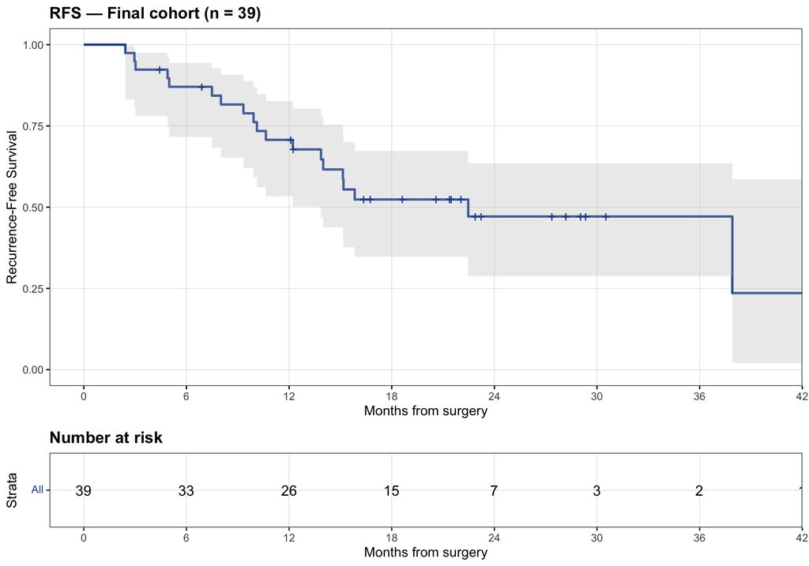

```r
fit_all <- survfit(Surv(RFS.months, RFS.Event) ~ 1, data = cohort, conf.type = "log-log")
ggsurvplot(fit_all, data = cohort, risk.table = TRUE, conf.int = TRUE, palette = "#1F4E9C",
           break.time.by = 6, title = "RFS — Final cohort (n = 39)", xlab = "Months from surgery",
           ylab = "Recurrence-Free Survival", legend = "none", ggtheme = theme_utuc())
```

```r
summary(fit_all, times = c(12, 24, 36), extend = TRUE)
```

```
## Call: survfit(formula = Surv(RFS.months, RFS.Event) ~ 1, data = cohort,
##     conf.type = "log-log")
##
##  time n.risk n.event survival std.err lower 95% CI upper 95% CI
##    12     26      11    0.707  0.0744        0.533        0.826
##    24      7       7    0.471  0.0911        0.288        0.635
##    36      2       0    0.471  0.0911        0.288        0.635
```

```r
# **Median number of time points in the post-definitive surveillance window**
surv_cohort <- cohort |> filter(!is.na(ctDNA.Surveillance))
cat(sprintf("Median # of surveillance time points: %s (%s–%s), n = %d patients\n",
            median(surv_cohort$Nsurvtps, na.rm = TRUE), min(surv_cohort$Nsurvtps, na.rm = TRUE),
            max(surv_cohort$Nsurvtps, na.rm = TRUE), nrow(surv_cohort)))
```

```
## Median # of surveillance time points: 3 (1–12), n = 31 patients
```

```r
cat("Total plasma samples (final cohort, OP tab):", sum(op$is_ct), "\n")
```

```
## Total plasma samples (final cohort, OP tab): 265
```

```r
# **Median of median interval of ctDNA time points and radiological imaging assessment**
median_interval_per_patient <- function(data, filter_expr) {
  data |> filter({{ filter_expr }}) |> arrange(PatientName, date.diff) |>
    group_by(PatientName) |> mutate(interval = date.diff - lag(date.diff)) |>
    summarise(median_interval = median(interval, na.rm = TRUE), .groups = "drop") |>
    filter(!is.na(median_interval))
}
cohort_summary <- function(pm, label) {
  tibble(Event_Type = label, Patients = nrow(pm),
         `Cohort median (days)` = median(pm$median_interval),
         `Cohort median (months)` = round(median(pm$median_interval) / DAYS_PER_MONTH, 2),
         `Min patient median` = min(pm$median_interval), `Max patient median` = max(pm$median_interval))
}
cad <- bind_rows(
  cohort_summary(median_interval_per_patient(op, Event == "ctDNA"), "ctDNA — all post-op draws"),
  cohort_summary(median_interval_per_patient(op, Event == "ctDNA" & ctDNA.Window == "Surveillance"), "ctDNA — surveillance window only"),
  cohort_summary(median_interval_per_patient(op, Event_type == "Imaging"), "Imaging — all")
)
show_tbl(cad, "Assessment cadence, final cohort (the original notebook used all 76 patients; see QC note)")
```

| Event_Type | Patients | Cohort median (days) | Cohort median (months) | Min patient median | Max patient median |
| --- | --- | --- | --- | --- | --- |
| ctDNA — all post-op draws | 38 | 82.25 | 2.7 | 24.5 | 163.5 |
| ctDNA — surveillance window only | 29 | 83 | 2.73 | 14 | 156 |
| Imaging — all | 26 | 136 | 4.47 | 0 | 532 |

# 4. Figure 2A — RFS by ctDNA status in the early post-operative (MRD) window

```r
# **RFS by ctDNA status at the early post-operative (MRD) window**
# Time 0 = date of the early post-operative ctDNA draw (RFS and ctDNA.timing are in days from surgery)
d_mrd_all <- cohort |>
  filter(!is.na(ctDNA.MRD)) |>
  transmute(Patient.ID, ctDNA.MRD, ctDNA.timing, RFS, RFS.Event,
            time  = (RFS - ctDNA.timing) / DAYS_PER_MONTH,
            event = as.numeric(RFS.Event),
            group = factor(ctDNA.MRD, levels = c("NEGATIVE", "POSITIVE")))

d_mrd_excluded <- d_mrd_all |> filter(is.na(time) | is.na(event) | is.na(group) | time <= 0)
if (nrow(d_mrd_excluded) > 0) {
  warning("Fig 2A: excluded ", nrow(d_mrd_excluded), " patient(s) with missing ctDNA.timing/RFS: ",
          paste(d_mrd_excluded$Patient.ID, collapse = ", "))
  print(select(d_mrd_excluded, Patient.ID, ctDNA.MRD, ctDNA.timing, RFS, RFS.Event))
}

d_mrd <- d_mrd_all |>
  filter(!is.na(time), !is.na(event), !is.na(group), time > 0) |>
  select(Patient.ID, time, event, group) |>
  as.data.frame()

cat(sprintf("Fig 2A cohort: %d patients, %d events | MRD-positive %d (%d events) | MRD-negative %d (%d events)\n",
            nrow(d_mrd), sum(d_mrd$event),
            sum(d_mrd$group == "POSITIVE"), sum(d_mrd$event[d_mrd$group == "POSITIVE"]),
            sum(d_mrd$group == "NEGATIVE"), sum(d_mrd$event[d_mrd$group == "NEGATIVE"])))
```

```
## Fig 2A cohort: 28 patients, 14 events | MRD-positive 14 (11 events) | MRD-negative 14 (3 events)
```

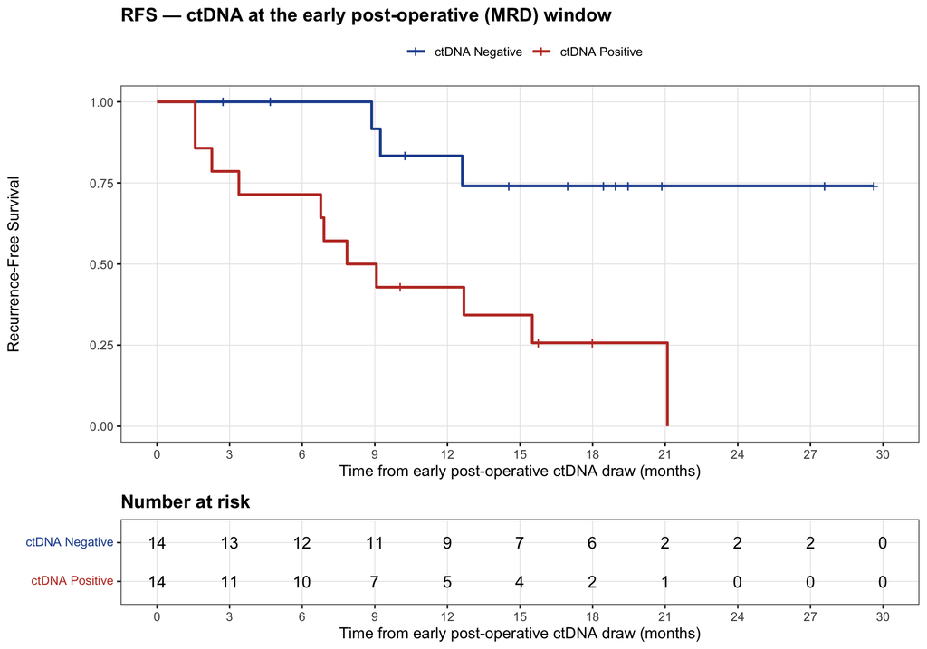

```r
res_mrd <- km_bundle(d_mrd, "RFS — ctDNA at the early post-operative (MRD) window",
                     "Time from early post-operative ctDNA draw (months)", 3, c(0, 6, 12, 18))
res_mrd$km
```

```r
show_tbl(res_mrd$events, "Events by MRD status")
```

| group | Total | Events | Event rate (%) |
| --- | --- | --- | --- |
| NEGATIVE | 14 | 3 | 21.4 |
| POSITIVE | 14 | 11 | 78.6 |

```r
res_mrd$km_times
```

```
## Call: survfit(formula = Surv(time, event) ~ group, data = d, conf.type = "log-log")
##
##                 group=NEGATIVE
##  time n.risk n.event survival std.err lower 95% CI upper 95% CI
##     0     14       0    1.000   0.000        1.000        1.000
##     6     12       0    1.000   0.000        1.000        1.000
##    12      9       2    0.833   0.108        0.482        0.956
##    18      6       1    0.741   0.129        0.391        0.909
##
##                 group=POSITIVE
##  time n.risk n.event survival std.err lower 95% CI upper 95% CI
##     0     14       0    1.000   0.000       1.0000        1.000
##     6     10       4    0.714   0.121       0.4063        0.882
##    12      5       4    0.429   0.132       0.1773        0.660
##    18      2       2    0.257   0.123       0.0667        0.506
```

```r
summary(res_mrd$cox)
```

```
## Call:
## coxph(formula = Surv(time, event) ~ group, data = d)
##
##   n= 28, number of events= 14
##
##                 coef exp(coef) se(coef)     z Pr(>|z|)
## groupPOSITIVE 1.6823    5.3779   0.6538 2.573   0.0101 *
## ---
## Signif. codes:  0 '***' 0.001 '**' 0.01 '*' 0.05 '.' 0.1 ' ' 1
##
##               exp(coef) exp(-coef) lower .95 upper .95
## groupPOSITIVE     5.378     0.1859     1.493     19.37
##
## Concordance= 0.704  (se = 0.055 )
## Likelihood ratio test= 8.34  on 1 df,   p=0.004
## Wald test            = 6.62  on 1 df,   p=0.01
## Score (logrank) test = 8.28  on 1 df,   p=0.004
```

```r
res_mrd$firth
```

```
## coxphf(formula = Surv(time, event) ~ group, data = d)
## Model fitted by Penalized ML
## Confidence intervals and p-values by Profile Likelihood
##
##                   coef  se(coef) exp(coef) lower 0.95 upper 0.95    Chisq
## groupPOSITIVE 1.569113 0.6348651  4.802388   1.581132   18.93223 7.964297
##                         p
## groupPOSITIVE 0.004770902
##
## Likelihood ratio test=7.964297 on 1 df, p=0.004770902, n=28
```

```r
show_tbl(res_mrd$hr, "Hazard ratios — MRD window")
```

| term | HR | lower | upper | p | method | n | events |
| --- | --- | --- | --- | --- | --- | --- | --- |
| groupPOSITIVE | 5.378 | 1.493 | 19.369 | 0.01 | Cox PH (Wald CI) | 28 | 14 |
| groupPOSITIVE | 4.802 | 1.581 | 18.932 | 0.005 | Firth penalized Cox (profile-likelihood CI) |  |  |

```r
cat(with(cox_tidy(res_mrd$cox), fmt_hr(HR, lower, upper, p)), "\n")
```

```
## HR = 5.38 (95% CI 1.49–19.37); P = 0.010
```

```r
res_mrd$zph
```

```
##        chisq df    p
## group  0.494  1 0.48
## GLOBAL 0.494  1 0.48
```

```r
res_mrd$fisher
```

```
##
##  Fisher's Exact Test for Count Data
##
## data:  tab
## p-value = 0.007028
## alternative hypothesis: true odds ratio is not equal to 1
## 95 percent confidence interval:
##    1.728154 119.546559
## sample estimates:
## odds ratio
##   11.90503
```

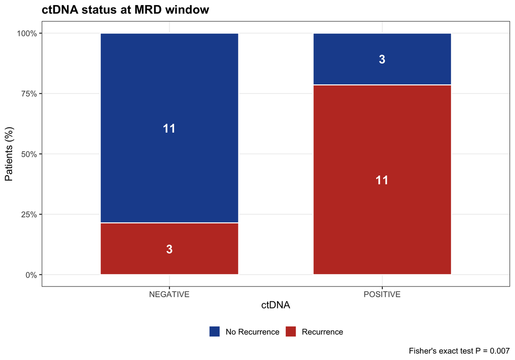

```r
print(stacked_bar(res_mrd$table, "ctDNA status at MRD window"))
```

```r
mrd_t <- cohort$ctDNA.timing[cohort$Patient.ID %in% d_mrd$Patient.ID]
cat(sprintf("Median time from surgery to MRD draw: %s days (range %s–%s)\n", median(mrd_t), min(mrd_t), max(mrd_t)))
```

```
## Median time from surgery to MRD draw: 51 days (range 10–106)
```

# 5. Figure 2B — RFS by ctDNA status in the post-definitive surveillance window

- **Time-fixed KM / Cox / Firth** — time 0 = surgery.
- **Time-dependent Cox** — counting-process format; time 0 = start of the post-definitive window; delayed entry at the first post-definitive draw.

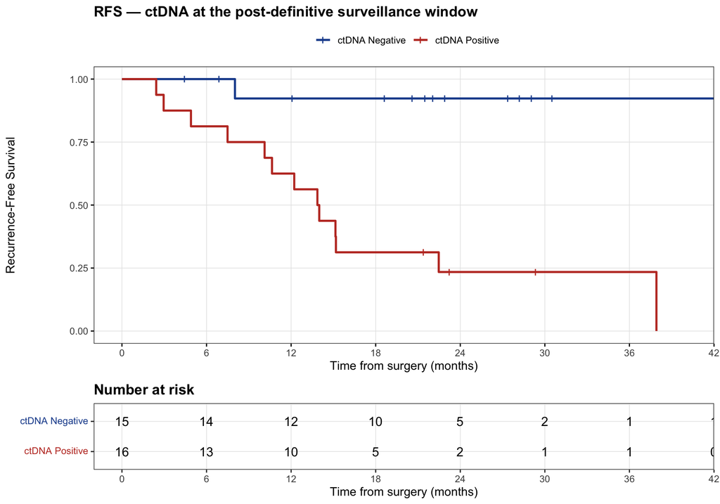

```r
# **RFS by ctDNA status at Surveillance window (time-fixed)**
d_surv <- surv_cohort |>
  transmute(Patient.ID, time = RFS.months, event = as.numeric(RFS.Event),
            group = factor(ctDNA.Surveillance, levels = c("NEGATIVE", "POSITIVE")),
            Age, Age10 = Age / 10, cStage, NAC = factor(NAC, c(FALSE, TRUE)), ACT = factor(ACT, c(FALSE, TRUE)))
res_surv <- km_bundle(d_surv, "RFS — ctDNA at the post-definitive surveillance window",
                      "Time from surgery (months)", 6, c(0, 12, 18, 24))
res_surv$km
```

```r
show_tbl(res_surv$events, "Events by surveillance status")
```

| group | Total | Events | Event rate (%) |
| --- | --- | --- | --- |
| NEGATIVE | 15 | 1 | 6.7 |
| POSITIVE | 16 | 13 | 81.2 |

```r
res_surv$km_times
```

```
## Call: survfit(formula = Surv(time, event) ~ group, data = d, conf.type = "log-log")
##
##                 group=NEGATIVE
##  time n.risk n.event survival std.err lower 95% CI upper 95% CI
##     0     15       0    1.000  0.0000        1.000        1.000
##    12     12       1    0.923  0.0739        0.566        0.989
##    18     10       0    0.923  0.0739        0.566        0.989
##    24      5       0    0.923  0.0739        0.566        0.989
##
##                 group=POSITIVE
##  time n.risk n.event survival std.err lower 95% CI upper 95% CI
##     0     16       0    1.000   0.000       1.0000        1.000
##    12     10       6    0.625   0.121       0.3486        0.811
##    18      5       5    0.312   0.116       0.1139        0.536
##    24      2       1    0.234   0.110       0.0647        0.463
```

```r
summary(res_surv$cox)
```

```
## Call:
## coxph(formula = Surv(time, event) ~ group, data = d)
##
##   n= 31, number of events= 14
##
##                 coef exp(coef) se(coef)     z Pr(>|z|)
## groupPOSITIVE  2.700    14.882    1.039 2.599  0.00935 **
## ---
## Signif. codes:  0 '***' 0.001 '**' 0.01 '*' 0.05 '.' 0.1 ' ' 1
##
##               exp(coef) exp(-coef) lower .95 upper .95
## groupPOSITIVE     14.88    0.06719     1.942       114
##
## Concordance= 0.729  (se = 0.059 )
## Likelihood ratio test= 13.79  on 1 df,   p=2e-04
## Wald test            = 6.75  on 1 df,   p=0.009
## Score (logrank) test = 11.91  on 1 df,   p=6e-04
```

```r
res_surv$firth
```

```
## coxphf(formula = Surv(time, event) ~ group, data = d)
## Model fitted by Penalized ML
## Confidence intervals and p-values by Profile Likelihood
##
##                   coef  se(coef) exp(coef) lower 0.95 upper 0.95    Chisq
## groupPOSITIVE 2.333271 0.8929133  10.31162   2.514973   94.48263 12.63712
##                          p
## groupPOSITIVE 0.0003781612
##
## Likelihood ratio test=12.63712 on 1 df, p=0.0003781612, n=31
```

```r
show_tbl(res_surv$hr, "Hazard ratios — surveillance window (time-fixed)")
```

| term | HR | lower | upper | p | method | n | events |
| --- | --- | --- | --- | --- | --- | --- | --- |
| groupPOSITIVE | 14.882 | 1.942 | 114.035 | 0.009 | Cox PH (Wald CI) | 31 | 14 |
| groupPOSITIVE | 10.312 | 2.515 | 94.483 | 0 | Firth penalized Cox (profile-likelihood CI) |  |  |

```r
res_surv$zph
```

```
##        chisq df    p
## group   0.62  1 0.43
## GLOBAL  0.62  1 0.43
```

```r
res_surv$fisher
```

```
##
##  Fisher's Exact Test for Count Data
##
## data:  tab
## p-value = 3.852e-05
## alternative hypothesis: true odds ratio is not equal to 1
## 95 percent confidence interval:
##     4.667184 2693.785138
## sample estimates:
## odds ratio
##   48.89764
```

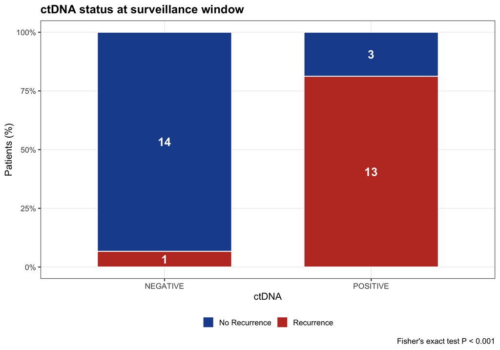

```r
print(stacked_bar(res_surv$table, "ctDNA status at surveillance window"))
```

```r
# **Time-dependent data: long-format biomarker and survival tables**
td <- td_raw |>
  mutate(Final.cohort = to_lgl(Final.cohort),
         ctDNA.Surveillance.Available = to_lgl(ctDNA.Surveillance.Available),
         Window.Start.Date = parse_date_any(Window.Start.Date),
         DFS.Date = parse_date_any(DFS.Date), DFS.Event = to_num(DFS.Event)) |>
  filter(Final.cohort, ctDNA.Surveillance.Available)

# NB: the original notebook used names_pattern "surveillance_(.)_(.*)", which silently dropped
# visits 10-12 (UTUC-010). "(\\d+)" captures all 12 visits.
td_long <- td |>
  select(Patient.ID, Window.Start.Date, matches("^Surveillance\\.\\d+\\.(Status|Date)$")) |>
  pivot_longer(-c(Patient.ID, Window.Start.Date), names_to = c("visit", ".value"),
               names_pattern = "^Surveillance\\.(\\d+)\\.(Status|Date)$") |>
  mutate(visit = as.integer(visit), Date = parse_date_any(Date)) |>
  filter(!is.na(Date), !is.na(Status)) |>
  mutate(biomarker_time = as.numeric(Date - Window.Start.Date))

td_surv <- td |>
  transmute(Patient.ID, dfs_time = as.numeric(DFS.Date - Window.Start.Date), dfs_event = DFS.Event)

cat("Patients:", nrow(td_surv), "| surveillance draws:", nrow(td_long),
    "| draws before window start (dropped):", sum(td_long$biomarker_time < 0),
    "| patients with dfs_time <= 0 (dropped):", sum(td_surv$dfs_time <= 0), "\n")
```

```
## Patients: 31 | surveillance draws: 129 | draws before window start (dropped): 0 | patients with dfs_time <= 0 (dropped): 0
```

```r
td_long <- td_long |> filter(biomarker_time >= 0)
td_surv <- td_surv |> filter(dfs_time > 0)

build_td <- function(surv_df, bio_df, same_day_shift = 0) {
  # same_day_shift > 0: a draw on the same day as the recurrence date is moved earlier by that
  # many days so it is treated as preceding the event (sensitivity analysis)
  bio <- bio_df |> left_join(surv_df, by = "Patient.ID") |>
    mutate(biomarker_time = ifelse(biomarker_time == dfs_time & dfs_event == 1,
                                   dfs_time - same_day_shift, biomarker_time)) |>
    select(Patient.ID, biomarker_time, Status)
  base <- tmerge(data1 = surv_df, data2 = surv_df, id = Patient.ID,
                 dfs_event = event(dfs_time, dfs_event))
  tmerge(data1 = base, data2 = bio, id = Patient.ID,
         biomarker_status = tdc(biomarker_time, Status)) |>
    mutate(biomarker_status = factor(biomarker_status, levels = c("NEGATIVE", "POSITIVE")))
}
dt_final <- build_td(td_surv, td_long)
show_tbl(dt_final, "Counting-process (start, stop] dataset; NA status = interval before first post-definitive draw (delayed entry)")
```

| Patient.ID | dfs_time | dfs_event | tstart | tstop | biomarker_status |
| --- | --- | --- | --- | --- | --- |
| UTUC-010 | 707 | 0 | 0 | 144 |  |
| UTUC-010 | 707 | 0 | 144 | 181 | NEGATIVE |
| UTUC-010 | 707 | 0 | 181 | 223 | NEGATIVE |
| UTUC-010 | 707 | 0 | 223 | 267 | NEGATIVE |
| UTUC-010 | 707 | 0 | 267 | 307 | NEGATIVE |
| UTUC-010 | 707 | 0 | 307 | 349 | NEGATIVE |
| UTUC-010 | 707 | 0 | 349 | 392 | NEGATIVE |
| UTUC-010 | 707 | 0 | 392 | 433 | POSITIVE |
| UTUC-010 | 707 | 0 | 433 | 475 | POSITIVE |
| UTUC-010 | 707 | 0 | 475 | 480 | POSITIVE |

[output cut: 141 more lines]

```r
# **Time-dependent Cox for RFS (primary, as submitted) and Firth version**
dt_model <- dt_final |> filter(!is.na(biomarker_status))
cat("Intervals:", nrow(dt_model), "| patients:", n_distinct(dt_model$Patient.ID),
    "| events in model:", sum(dt_model$dfs_event), "of", sum(td_surv$dfs_event), "\n")
```

```
## Intervals: 120 | patients: 30 | events in model: 13 of 14
```

```r
lost <- dt_final |> filter(is.na(biomarker_status), dfs_event == 1)
if (nrow(lost) > 0) { cat("Events occurring before the first post-definitive draw (not in risk set):\n"); print(lost) }
```

```
## Events occurring before the first post-definitive draw (not in risk set):
##   Patient.ID dfs_time dfs_event tstart tstop biomarker_status
## 1   UTUC-043       72         1      0    72             <NA>
```

```r
fit_td   <- coxph(Surv(tstart, tstop, dfs_event) ~ biomarker_status, data = dt_model)
fit_td_f <- coxphf(Surv(tstart, tstop, dfs_event) ~ biomarker_status, data = dt_model)
summary(fit_td)
```

```
## Call:
## coxph(formula = Surv(tstart, tstop, dfs_event) ~ biomarker_status,
##     data = dt_model)
##
##   n= 120, number of events= 13
##
##                           coef exp(coef) se(coef)     z Pr(>|z|)
## biomarker_statusPOSITIVE  3.75     42.54     1.06 3.537 0.000405 ***
## ---
## Signif. codes:  0 '***' 0.001 '**' 0.01 '*' 0.05 '.' 0.1 ' ' 1
##
##                          exp(coef) exp(-coef) lower .95 upper .95
## biomarker_statusPOSITIVE     42.54    0.02351     5.323       340
##
## Concordance= 0.844  (se = 0.061 )
## Likelihood ratio test= 27.13  on 1 df,   p=2e-07
## Wald test            = 12.51  on 1 df,   p=4e-04
## Score (logrank) test = 29.96  on 1 df,   p=4e-08
```

```r
fit_td_f
```

```
## coxphf(formula = Surv(tstart, tstop, dfs_event) ~ biomarker_status,
##     data = dt_model)
## Model fitted by Penalized ML
## Confidence intervals and p-values by Profile Likelihood
##
##                              coef  se(coef) exp(coef) lower 0.95 upper 0.95
## biomarker_statusPOSITIVE 3.397248 0.9280624  29.88176   6.784639   282.7984
##                             Chisq            p
## biomarker_statusPOSITIVE 26.27448 2.961768e-07
##
## Likelihood ratio test=26.27448 on 1 df, p=2.961768e-07, n=120
```

```r
td_hr <- bind_rows(cox_tidy(fit_td, "Time-dependent"), firth_tidy(fit_td_f, "Time-dependent"))
show_tbl(td_hr, "Time-dependent ctDNA status — RFS")
```

| term | HR | lower | upper | p | method | n | events | model |
| --- | --- | --- | --- | --- | --- | --- | --- | --- |
| biomarker_statusPOSITIVE | 42.542 | 5.323 | 340.019 | 0 | Cox PH (Wald CI) | 120 | 13 | Time-dependent |
| biomarker_statusPOSITIVE | 29.882 | 6.785 | 282.798 | 0 | Firth penalized Cox (profile-likelihood CI) |  |  | Time-dependent |

```r
cat(with(cox_tidy(fit_td), fmt_hr(HR, lower, upper, p)), "\n")
```

```
## HR = 42.54 (95% CI 5.32–340.02); P < 0.001
```

```r
# **Status transitions per patient**
trans <- td_long |> arrange(Patient.ID, biomarker_time) |> group_by(Patient.ID) |>
  summarise(draws = n(), first_draw_day = min(biomarker_time),
            switches = sum(Status != lag(Status), na.rm = TRUE),
            pattern = paste(substr(Status, 1, 3), collapse = "→"), .groups = "drop")
show_tbl(trans, "Surveillance status sequence and number of status switches per patient")
```

| Patient.ID | draws | first_draw_day | switches | pattern |
| --- | --- | --- | --- | --- |
| UTUC-010 | 12 | 144 | 1 | NEG→NEG→NEG→NEG→NEG→NEG→POS→POS→POS→POS→POS→POS |
| UTUC-011 | 5 | 74 | 1 | NEG→POS→POS→POS→POS |
| UTUC-012 | 5 | 107 | 0 | NEG→NEG→NEG→NEG→NEG |
| UTUC-015 | 6 | 78 | 0 | NEG→NEG→NEG→NEG→NEG→NEG |
| UTUC-019 | 1 | 178 | 0 | POS |
| UTUC-022 | 2 | 202 | 0 | POS→POS |
| UTUC-026 | 2 | 42 | 0 | POS→POS |
| UTUC-027 | 6 | 21 | 1 | NEG→NEG→NEG→NEG→POS→POS |
| UTUC-030 | 3 | 74 | 0 | NEG→NEG→NEG |
| UTUC-031 | 2 | 26 | 0 | POS→POS |

[output cut: 21 more lines]

```r
cat("Patients with ≥1 switch:", sum(trans$switches > 0), "| with ≥2 switches:", sum(trans$switches >= 2), "\n")
```

```
## Patients with ≥1 switch: 10 | with ≥2 switches: 0
```

```r
# **Sensitivity 1: same-day draw treated as preceding recurrence imaging**
dt_shift <- build_td(td_surv, td_long, same_day_shift = 0.5) |> filter(!is.na(biomarker_status))
fit_shift   <- coxph(Surv(tstart, tstop, dfs_event) ~ biomarker_status, data = dt_shift)
fit_shift_f <- coxphf(Surv(tstart, tstop, dfs_event) ~ biomarker_status, data = dt_shift)

sens <- bind_rows(
  bind_cols(tibble(Analysis = "Primary time-dependent (as submitted)", events = fit_td$nevent), cox_tidy(fit_td) |> select(HR, lower, upper, p)),
  bind_cols(tibble(Analysis = "Primary time-dependent, Firth", events = fit_td$nevent), firth_tidy(fit_td_f) |> select(HR, lower, upper, p)),
  bind_cols(tibble(Analysis = "Same-day draw precedes imaging (Cox)", events = fit_shift$nevent), cox_tidy(fit_shift) |> select(HR, lower, upper, p)),
  bind_cols(tibble(Analysis = "Same-day draw precedes imaging (Firth)", events = fit_shift$nevent), firth_tidy(fit_shift_f) |> select(HR, lower, upper, p))
)
show_tbl(sens, "Time-dependent model sensitivity analyses")
```

| Analysis | events | HR | lower | upper | p |
| --- | --- | --- | --- | --- | --- |
| Primary time-dependent (as submitted) | 13 | 42.542 | 5.323 | 340.019 | 0 |
| Primary time-dependent, Firth | 13 | 29.882 | 6.785 | 282.798 | 0 |
| Same-day draw precedes imaging (Cox) | 14 | 46.646 | 5.904 | 368.528 | 0 |
| Same-day draw precedes imaging (Firth) | 14 | 32.624 | 7.556 | 306.207 | 0 |

# 6. Figure 3A/B — ctDNA dynamics in the surveillance window

```r
# **Figure 3A — ctDNA dynamics in patients persistently ctDNA-negative during surveillance**
dyn <- mtm |> filter(!is.na(ctDNA.Surveillance)) |>
  group_by(PatientName) |> filter(n() >= 2) |> ungroup() |>
  mutate(MTM_plot = ifelse(MTM.mL == 0, 0.005, MTM.mL),
         Outcome  = factor(RFS.Event, c(FALSE, TRUE), c("No recurrence", "Recurrence")))

dyn |> distinct(PatientName, ctDNA.Surveillance, Outcome) |> count(ctDNA.Surveillance, Outcome) |>
  show_tbl("Patients per panel (≥2 post-operative time points)")
```

[output not shown]

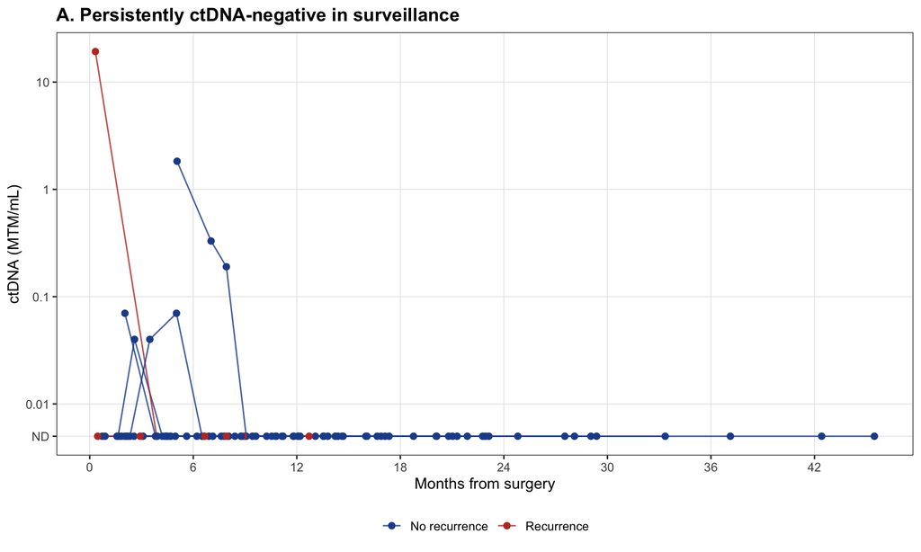

```r
plot_dyn <- function(status, title) {
  ggplot(filter(dyn, ctDNA.Surveillance == status),
         aes(date.diff.months, MTM_plot, group = PatientName, colour = Outcome)) +
    geom_line(alpha = 0.8) + geom_point(size = 2) +
    scale_y_log10(breaks = c(0.005, 0.01, 0.1, 1, 10, 100, 1000), labels = c("ND", "0.01", "0.1", "1", "10", "100", "1000")) +
    scale_x_continuous(breaks = seq(0, 72, by = 6)) +
    scale_colour_manual(values = c("No recurrence" = pal_ctdna[1], "Recurrence" = pal_ctdna[2])) +
    labs(title = title, x = "Months from surgery", y = "ctDNA (MTM/mL)", colour = NULL) + theme_utuc()
}
p3a <- plot_dyn("NEGATIVE", "A. Persistently ctDNA-negative in surveillance"); p3a
```

```r
save_fig(p3a, "Fig3A_dynamics_negative")
```

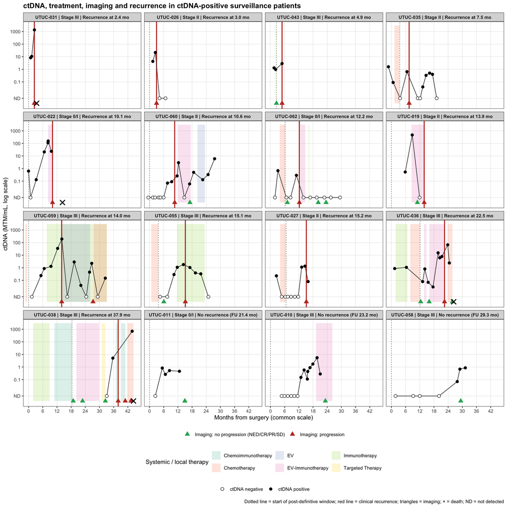

```r
# **Figure 3B (revised) — per-patient timelines for the 16 ctDNA-positive surveillance patients**
pos_ids <- surv_cohort |> filter(ctDNA.Surveillance == "POSITIVE") |>
  left_join(select(td, Patient.ID, Window.Start.Date), by = "Patient.ID") |>
  transmute(PatientName = Patient.ID, Stage, RFS.Event, RFS.months, OS.months,
            window_mo = as.numeric(Window.Start.Date - Surgery.Date) / DAYS_PER_MONTH) |>
  arrange(desc(RFS.Event), RFS.months) |>
  mutate(panel = paste0(PatientName, " | Stage ", Stage, " | ",
                        ifelse(RFS.Event, sprintf("Recurrence at %.1f mo", RFS.months), sprintf("No recurrence (FU %.1f mo)", OS.months))),
         panel = factor(panel, levels = panel))

tl   <- op |> filter(PatientName %in% pos_ids$PatientName) |> left_join(select(pos_ids, PatientName, panel), by = "PatientName")
ctl  <- tl |> filter(Event_type %in% c("ctDNA_pos", "ctDNA_neg")) |>
  mutate(MTM_plot = ifelse(MTM.mL == 0 | is.na(MTM.mL), 0.005, MTM.mL),
         Status = ifelse(Event_type == "ctDNA_pos", "ctDNA positive", "ctDNA negative"))
txl  <- tl |> filter(!is.na(Tx_type), !is.na(Tx_start.months)) |> distinct(panel, Tx_type, Tx_start.months, Tx_end.months)
img  <- tl |> filter(Event_type == "Imaging") |>
  mutate(Imaging = ifelse(Event == "PD", "Imaging: progression", "Imaging: no progression (NED/CR/PR/SD)"))
dth  <- tl |> filter(Event_type == "Death")

p3b_new <- ggplot() +
  geom_rect(data = txl, aes(xmin = Tx_start.months, xmax = pmax(Tx_end.months, Tx_start.months + 0.3),
                            ymin = 0.002, ymax = 3000, fill = Tx_type), alpha = 0.22) +
  geom_vline(data = pos_ids, aes(xintercept = window_mo), linetype = "dotted", colour = "grey35") +
  geom_vline(data = filter(pos_ids, RFS.Event), aes(xintercept = RFS.months), colour = "#C0392B", linewidth = 0.9) +
  geom_line(data = ctl, aes(date.diff.months, MTM_plot), colour = "grey25") +
  geom_point(data = ctl, aes(date.diff.months, MTM_plot, shape = Status), size = 2.4, fill = "white") +
  geom_point(data = img, aes(date.diff.months, 0.002, colour = Imaging), shape = 17, size = 3) +
  geom_point(data = dth, aes(date.diff.months, 0.002), shape = 4, size = 3, stroke = 1.3) +
  facet_wrap(~ panel, ncol = 4) +
  scale_shape_manual(values = c("ctDNA positive" = 16, "ctDNA negative" = 21), name = NULL) +
  scale_colour_manual(values = c("Imaging: progression" = "#C0392B", "Imaging: no progression (NED/CR/PR/SD)" = "#27AE60"), name = NULL) +
  scale_fill_brewer(palette = "Set2", name = "Systemic / local therapy") +
  scale_y_log10(breaks = c(0.005, 0.1, 1, 10, 100, 1000), labels = c("ND", "0.1", "1", "10", "100", "1000"),
                limits = c(0.0015, 3000)) +
  scale_x_continuous(breaks = seq(0, 60, by = 6)) +
  coord_cartesian(xlim = c(0, max(c(pos_ids$OS.months, ctl$date.diff.months), na.rm = TRUE) + 1)) +
  labs(x = "Months from surgery (common scale)", y = "ctDNA (MTM/mL, log scale)",
       title = "ctDNA, treatment, imaging and recurrence in ctDNA-positive surveillance patients",
       caption = "Dotted line = start of post-definitive window; red line = clinical recurrence; triangles = imaging; × = death; ND = not detected") +
  theme_utuc(11) + theme(strip.text = element_text(size = 8.5, face = "bold"), legend.box = "vertical")
p3b_new
```

```r
save_fig(p3b_new, "Fig3B_patient_timelines", w = 15, h = 14)
```

# 7. Figure 3C — Lead time

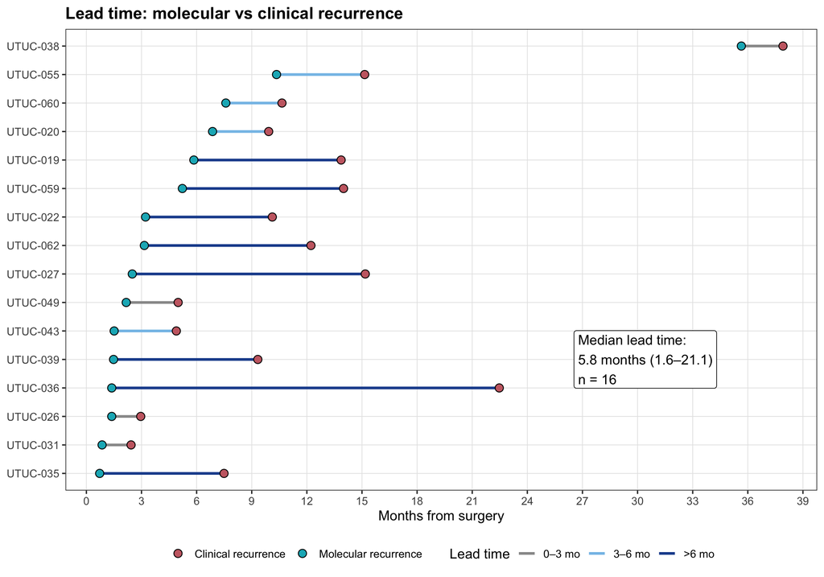

```r
# **Figure 3C — lead time from first post-operative ctDNA-positive result to radiographic recurrence**
ltd <- lt |> mutate(MR_mo = MR / DAYS_PER_MONTH, CR_mo = CR / DAYS_PER_MONTH, LT_mo = LT / DAYS_PER_MONTH,
                    lt_cat = cut(LT_mo, c(-Inf, 3, 6, Inf), labels = c("0–3 mo", "3–6 mo", ">6 mo"))) |>
  arrange(pmin(MR_mo, CR_mo)) |> mutate(PatientID = factor(PatientID, levels = PatientID))

annot <- sprintf("Median lead time:\n%.1f months (%.1f–%.1f)\nn = %d",
                 median(ltd$LT_mo), min(ltd$LT_mo), max(ltd$LT_mo), nrow(ltd))
p3c <- ggplot(ltd) +
  geom_segment(aes(x = MR_mo, xend = CR_mo, y = PatientID, yend = PatientID, colour = lt_cat), linewidth = 1.1) +
  geom_point(aes(MR_mo, PatientID, fill = "Molecular recurrence"), shape = 21, size = 3) +
  geom_point(aes(CR_mo, PatientID, fill = "Clinical recurrence"), shape = 21, size = 3) +
  scale_colour_manual(values = c("0–3 mo" = "grey60", "3–6 mo" = "#85C1E9", ">6 mo" = "#1F4E9C"), name = "Lead time") +
  scale_fill_manual(values = c("Molecular recurrence" = "#10B4C1", "Clinical recurrence" = "#C96A72"), name = NULL) +
  annotate("label", x = max(ltd$CR_mo) * 0.70, y = levels(ltd$PatientID)[ceiling(nlevels(ltd$PatientID) * 0.3)],
           label = annot, hjust = 0) +
  scale_x_continuous(breaks = seq(0, 48, by = 3)) +
  labs(x = "Months from surgery", y = NULL, title = "Lead time: molecular vs clinical recurrence") + theme_utuc()
p3c
```

```r
save_fig(p3c, "Fig3C_lead_time")

wil <- wilcox.test(ltd$CR, ltd$MR, paired = TRUE, conf.int = TRUE, exact = FALSE)
cat(sprintf("Paired Wilcoxon: n = %d, V = %g, P %s; Hodges–Lehmann median difference = %.1f days (95%% CI %.1f–%.1f)\n",
            nrow(ltd), wil$statistic, fmt_p(wil$p.value), wil$estimate, wil$conf.int[1], wil$conf.int[2]))
```

```
## Paired Wilcoxon: n = 16, V = 136, P < 0.001; Hodges–Lehmann median difference = 171.3 days (95% CI 103.0–255.5)
```

# 8. Figure 3D — ctDNA growth rate (continuous)

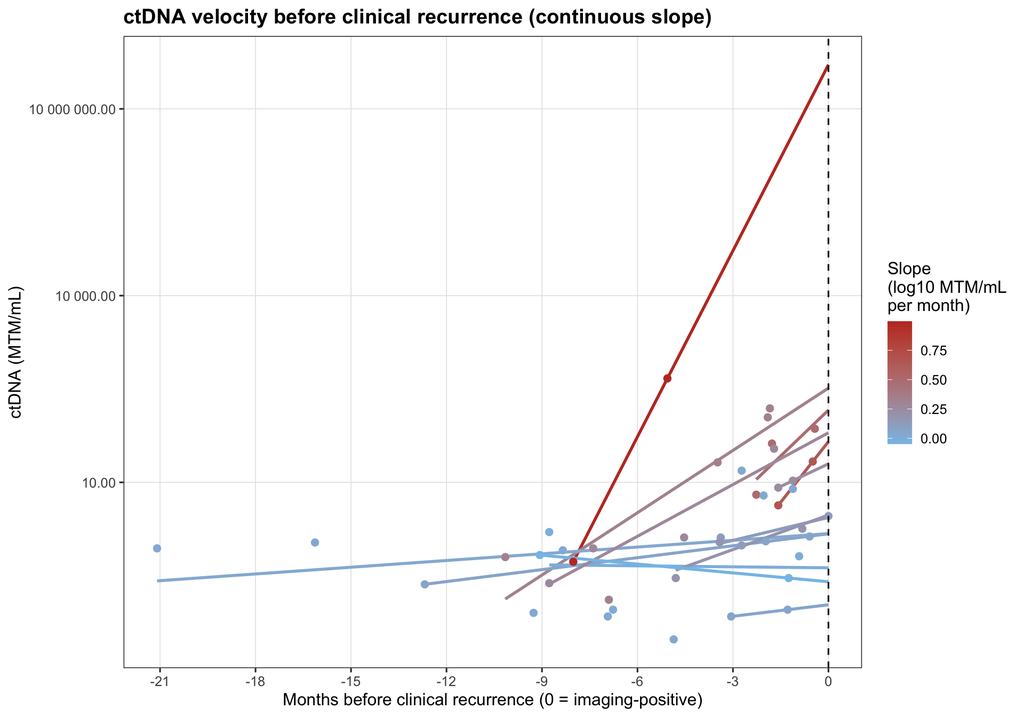

```r
# **Figure 3D — ctDNA growth rate before clinical recurrence (per-patient log-linear fits, continuous slope)**
preCR <- vel |> filter(daysCR.months <= 0, is.finite(MTM.mL), MTM.mL > 0)
eligible <- preCR |> group_by(PatientName) |> filter(n() >= 2, n_distinct(daysCR.months) >= 2) |> ungroup()

slopes <- eligible |> group_by(PatientName) |>
  summarise(n_points = n(),
            slope = coef(lm(log10(MTM.mL) ~ daysCR.months))[["daysCR.months"]],
            lead_time_mo = -min(daysCR.months),
            max_MTM = max(MTM.mL), .groups = "drop")

pred_lines <- eligible |> group_by(PatientName) |> group_modify(function(dd, k) {
  m <- lm(log10(MTM.mL) ~ daysCR.months, data = dd)
  g <- tibble(daysCR.months = seq(min(dd$daysCR.months), 0, length.out = 50))
  g |> mutate(MTM.mL = 10^predict(m, newdata = g))
}) |> ungroup() |> left_join(select(slopes, PatientName, slope), by = "PatientName")

p3d <- ggplot() +
  geom_line(data = pred_lines, aes(daysCR.months, MTM.mL, group = PatientName, colour = slope), linewidth = 1) +
  geom_point(data = left_join(eligible, select(slopes, PatientName, slope), by = "PatientName"),
             aes(daysCR.months, MTM.mL, colour = slope), size = 2) +
  geom_vline(xintercept = 0, linetype = "dashed") +
  scale_y_log10(labels = label_number(accuracy = 0.01)) +
  scale_colour_gradient(low = "#85C1E9", high = "#C0392B", name = "Slope\n(log10 MTM/mL\nper month)") +
  scale_x_continuous(breaks = seq(-24, 0, by = 3)) +
  labs(x = "Months before clinical recurrence (0 = imaging-positive)", y = "ctDNA (MTM/mL)",
       title = "ctDNA velocity before clinical recurrence (continuous slope)") +
  theme_utuc() + theme(legend.position = "right")
p3d
```

```r
save_fig(p3d, "Fig3D_velocity_continuous")

cat(sprintf("Patients with ≥2 positive pre-recurrence draws: %d\n", nrow(slopes)))
```

```
## Patients with ≥2 positive pre-recurrence draws: 13
```

```r
show_tbl(slopes, "Per-patient ctDNA growth rate")
```

| PatientName | n_points | slope | lead_time_mo | max_MTM |
| --- | --- | --- | --- | --- |
| UTUC-019 | 2 | 0.996 | 8.017 | 467.44 |
| UTUC-022 | 5 | 0.334 | 10.152 | 154.48 |
| UTUC-026 | 2 | 0.649 | 1.577 | 21.6 |
| UTUC-027 | 3 | 0.064 | 12.682 | 1.35 |
| UTUC-028 | 3 | 0.492 | 2.267 | 72.65 |
| UTUC-031 | 2 | 0.242 | 1.577 | 10.64 |
| UTUC-035 | 3 | -0.005 | 8.772 | 1.59 |
| UTUC-036 | 9 | 0.036 | 21.093 | 15.43 |
| UTUC-043 | 3 | 0.122 | 3.384 | 2.87 |
| UTUC-055 | 3 | 0.185 | 4.797 | 1.8 |

[output cut: 3 more lines]

```r
# **Association between continuous ctDNA slope and lead time**
sp <- cor.test(slopes$slope, slopes$lead_time_mo, method = "spearman", exact = FALSE)
cat(sprintf("Spearman rho (slope vs lead time) = %.2f, P %s, n = %d\n", sp$estimate, fmt_p(sp$p.value), nrow(slopes)))
```

```
## Spearman rho (slope vs lead time) = -0.45, P = 0.119, n = 13
```

```r
sp2 <- cor.test(slopes$slope, log10(slopes$max_MTM), method = "spearman", exact = FALSE)
cat(sprintf("Spearman rho (slope vs peak MTM/mL) = %.2f, P %s\n", sp2$estimate, fmt_p(sp2$p.value)))
```

```
## Spearman rho (slope vs peak MTM/mL) = 0.83, P < 0.001
```

```r
lm_lead <- lm(log(lead_time_mo) ~ slope, data = slopes)
summary(lm_lead)
```

```
##
## Call:
## lm(formula = log(lead_time_mo) ~ slope, data = slopes)
##
## Residuals:
##     Min      1Q  Median      3Q     Max
## -1.2660 -0.6966  0.2428  0.6706  1.1561
##
## Coefficients:
##             Estimate Std. Error t value Pr(>|t|)
## (Intercept)   1.9227     0.3097   6.209 6.64e-05 ***
## slope        -0.8293     0.7969  -1.041     0.32
## ---
## Signif. codes:  0 '***' 0.001 '**' 0.01 '*' 0.05 '.' 0.1 ' ' 1
##
## Residual standard error: 0.8246 on 11 degrees of freedom
## Multiple R-squared:  0.08962,    Adjusted R-squared:  0.006857
## F-statistic: 1.083 on 1 and 11 DF,  p-value: 0.3204
```

```r
cat(sprintf("Slope: median %.3f (IQR %.3f–%.3f) log10 MTM/mL per month\n",
            median(slopes$slope), quantile(slopes$slope, 0.25), quantile(slopes$slope, 0.75)))
```

```
## Slope: median 0.185 (IQR 0.062–0.334) log10 MTM/mL per month
```

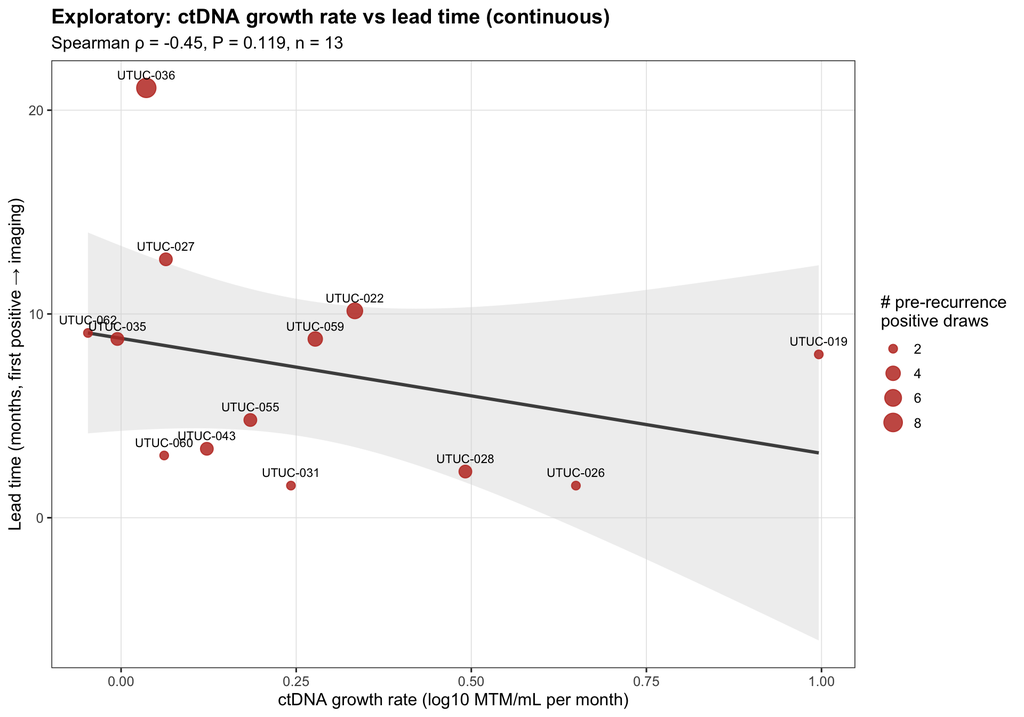

```r
p_slope <- ggplot(slopes, aes(slope, lead_time_mo)) +
  geom_smooth(method = "lm", formula = y ~ x, se = TRUE, colour = "grey30", fill = "grey85") +
  geom_point(aes(size = n_points), colour = pal_ctdna[2], alpha = 0.85) +
  geom_text(aes(label = PatientName), vjust = -1, size = 3) +
  scale_size_continuous(range = c(2.5, 6), name = "# pre-recurrence\npositive draws") +
  labs(x = "ctDNA growth rate (log10 MTM/mL per month)", y = "Lead time (months, first positive → imaging)",
       title = "Exploratory: ctDNA growth rate vs lead time (continuous)",
       subtitle = sprintf("Spearman ρ = %.2f, P %s, n = %d", sp$estimate, fmt_p(sp$p.value), nrow(slopes))) +
  theme_utuc() + theme(legend.position = "right")
p_slope
```

```r
save_fig(p_slope, "Fig3D_alt_slope_vs_leadtime")
```

# 9. Supplementary analyses cited in the response to reviewers

## 9.1 Recurrence site and ctDNA detection by site (Reviewer 1, comment 4)

```r
# **Recurrence site classification (CONFIRM entries marked with a clinician)**
site_map <- tribble(
  ~Patient.ID, ~Site.category, ~Site.detail,
  "UTUC-019", "Distant",      "Peritoneum",
  "UTUC-020", "Distant",      "Lung, liver, RP node",
  "UTUC-022", "Distant",      "Abdominal wall, bone",
  "UTUC-026", "Locoregional", "Right psoas, distal right ureter mass",
  "UTUC-027", "Distant",      "Right 1st rib",
  "UTUC-028", "Distant",      "Liver, bone, lymph nodes",
  "UTUC-031", "Distant",      "Liver, RP, serosal implants",
  "UTUC-035", "Distant",      "Liver, RP node",
  "UTUC-036", "Distant",      "Supraclavicular + RP LAD (supraclavicular = non-regional) — CONFIRM",
  "UTUC-038", "Distant",      "LN + lung metastases",
  "UTUC-039", "Distant",      "Mediastinal & AP-window LAD — CONFIRM",
  "UTUC-043", "Distant",      "Lung & liver",
  "UTUC-049", "Locoregional", "Adrenal + RP — CONFIRM (ipsilateral bed vs distant)",
  "UTUC-050", "Locoregional", "Sub-cm RP node",
  "UTUC-055", "Locoregional", "Para-aortic LN",
  "UTUC-059", "Locoregional", "Surgical bed",
  "UTUC-060", "Distant",      "Pubic bone",
  "UTUC-062", "Locoregional", "Para-aortic LN",
  "UTUC-073", "Intravesical", "Bladder (no distant disease)"
)
rec <- cohort |> filter(RFS.Event) |> select(Patient.ID, Stage, Recurrence.site, RFS, RFS.months, ctDNA.MRD, ctDNA.Surveillance) |>
  left_join(site_map, by = "Patient.ID")
if (any(is.na(rec$Site.category))) warning("Unmapped recurrences: ", paste(rec$Patient.ID[is.na(rec$Site.category)], collapse = ", "))

# Was ctDNA detected in the post-definitive window before / on the recurrence date?
first_pos <- op |> filter(Event_type == "ctDNA_pos", ctDNA.Window == "Surveillance") |>
  group_by(PatientName) |> summarise(first_surv_pos_day = min(date.diff), .groups = "drop")
first_pos_any <- op |> filter(Event_type == "ctDNA_pos", date.diff > 0) |>
  group_by(PatientName) |> summarise(first_postop_pos_day = min(date.diff), .groups = "drop")
rec <- rec |> left_join(first_pos, by = c("Patient.ID" = "PatientName")) |>
  left_join(first_pos_any, by = c("Patient.ID" = "PatientName")) |>
  mutate(RFS.day = RFS,
         Surveillance.detection = case_when(is.na(ctDNA.Surveillance) ~ "Not in surveillance cohort",
                                            is.na(first_surv_pos_day) ~ "ctDNA-negative",
                                            first_surv_pos_day < RFS.day ~ "Detected before recurrence",
                                            TRUE ~ "Detected at recurrence (same day)"))
show_tbl(rec, "All recurrences in the final cohort, by anatomical site")
```

| Patient.ID | Stage | Recurrence.site | RFS | RFS.months | ctDNA.MRD | ctDNA.Surveillance | Site.category | Site.detail | first_surv_pos_day | first_postop_pos_day | RFS.day | Surveillance.detection |
| --- | --- | --- | --- | --- | --- | --- | --- | --- | --- | --- | --- | --- |
| UTUC-019 | II | peritoneum | 422 | 13.865 |  | POSITIVE | Distant | Peritoneum | 178 | 178 | 422 | Detected before recurrence |
| UTUC-020 | III | lung, liver, RP node | 302 | 9.922 | NEGATIVE |  | Distant | Lung, liver, RP node |  | 209 | 302 | Not in surveillance cohort |
| UTUC-022 | 0/I | Abdominal wall, bones | 308 | 10.119 | POSITIVE | POSITIVE | Distant | Abdominal wall, bone | 202 | 98 | 308 | Detected before recurrence |
| UTUC-026 | II | Right psoas, distal right ureter mass | 90 | 2.957 | POSITIVE | POSITIVE | Locoregional | Right psoas, distal right ureter mass | 42 | 42 | 90 | Detected before recurrence |
| UTUC-027 | II | right 1st rib | 462 | 15.179 | POSITIVE | POSITIVE | Distant | Right 1st rib | 402 | 76 | 462 | Detected before recurrence |
| UTUC-028 | III | liver, bone, and lymph nodes | 92 | 3.023 | POSITIVE |  | Distant | Liver, bone, lymph nodes | 79 | 23 | 92 | Not in surveillance cohort |
| UTUC-031 | III | liver, RP, and serosal implants | 74 | 2.431 | POSITIVE | POSITIVE | Distant | Liver, RP, serosal implants | 26 | 26 | 74 | Detected before recurrence |
| UTUC-035 | II | liver, RP node | 228 | 7.491 | POSITIVE | POSITIVE | Distant | Liver, RP node | 200 | 22 | 228 | Detected before recurrence |
| UTUC-036 | III | Supraclavicle &amp; RP LAD | 684 | 22.473 | POSITIVE | POSITIVE | Distant | Supraclavicular + RP LAD (supraclavicular = non-regional) — CONFIRM | 402 | 42 | 684 | Detected before recurrence |
| UTUC-038 | III | LN, Lung Mets | 1154 | 37.914 |  | POSITIVE | Distant | LN + lung metastases | 1085 | 1085 | 1154 | Detected before recurrence |

[output cut: 9 more lines]

```r
bind_rows(
  rec |> count(Site.category) |> mutate(Cohort = "Final cohort (n = 39)"),
  rec |> filter(!is.na(ctDNA.Surveillance)) |> count(Site.category) |> mutate(Cohort = "Surveillance cohort (n = 31)"),
  rec |> filter(!is.na(ctDNA.MRD)) |> count(Site.category) |> mutate(Cohort = "MRD cohort (n = 28)")
) |> pivot_wider(names_from = Site.category, values_from = n, values_fill = 0) |> show_tbl("Recurrence site counts")
```

| Cohort | Distant | Intravesical | Locoregional |
| --- | --- | --- | --- |
| Final cohort (n = 39) | 12 | 1 | 6 |
| Surveillance cohort (n = 31) | 9 | 1 | 4 |
| MRD cohort (n = 28) | 10 | 0 | 4 |

```r
rec |> filter(!is.na(ctDNA.Surveillance)) |> count(Site.category, ctDNA.Surveillance, Surveillance.detection) |>
  show_tbl("Surveillance cohort: ctDNA detection by recurrence site")
```

| Site.category | ctDNA.Surveillance | Surveillance.detection | n |
| --- | --- | --- | --- |
| Distant | POSITIVE | Detected at recurrence (same day) | 1 |
| Distant | POSITIVE | Detected before recurrence | 8 |
| Intravesical | NEGATIVE | ctDNA-negative | 1 |
| Locoregional | POSITIVE | Detected before recurrence | 4 |

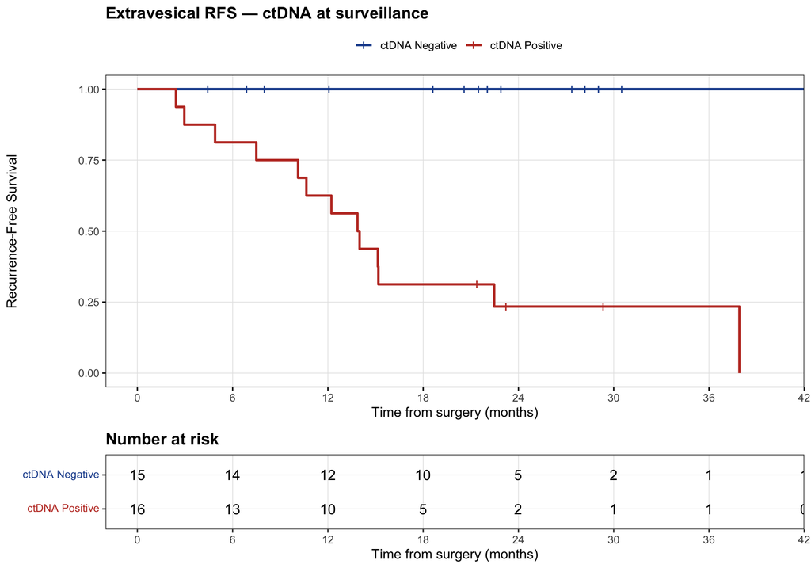

```r
# **Sensitivity: extravesical recurrence only (intravesical recurrence censored at its date)**
d_extra <- d_surv |> left_join(select(rec, Patient.ID, Site.category), by = "Patient.ID") |>
  mutate(event = ifelse(!is.na(Site.category) & Site.category == "Intravesical", 0, event))
res_extra <- km_bundle(d_extra, "Extravesical RFS — ctDNA at surveillance", "Time from surgery (months)", 6, c(12, 24))
res_extra$km
```

```r
show_tbl(res_extra$hr, "Extravesical RFS — surveillance ctDNA (time-fixed)")
```

| term | HR | lower | upper | p | method | n | events |
| --- | --- | --- | --- | --- | --- | --- | --- |
| groupPOSITIVE | 1882570763.772 | 0 |  | 0.998 | Cox PH (Wald CI) | 31 | 13 |
| groupPOSITIVE | 31.157 | 4.129 | 3989.796 | 0 | Firth penalized Cox (profile-likelihood CI) |  |  |

## 9.2 ctDNA-positive patients without documented recurrence (Reviewer 1, comment 5)

```r
# **Case-level summary of MRD-positive patients without recurrence**
discordant_ids <- bind_rows(
  cohort |> filter(ctDNA.MRD == "POSITIVE", !RFS.Event) |> transmute(Patient.ID, Window = "Early post-operative (MRD)"),
  cohort |> filter(ctDNA.Surveillance == "POSITIVE", !RFS.Event) |> transmute(Patient.ID, Window = "Post-definitive surveillance")
)
ct <- op |> filter(is_ct, date.diff > 0)
case_summary <- discordant_ids |> rowwise() |> mutate(
  draws        = sum(ct$PatientName == Patient.ID),
  positives    = sum(ct$PatientName == Patient.ID & ct$Event_type == "ctDNA_pos"),
  first_pos_mo = round(min(ct$date.diff.months[ct$PatientName == Patient.ID & ct$Event_type == "ctDNA_pos"]), 1),
  max_MTM      = max(ct$MTM.mL[ct$PatientName == Patient.ID], na.rm = TRUE),
  MTM_series   = paste(ct$MTM.mL[ct$PatientName == Patient.ID][order(ct$date.diff[ct$PatientName == Patient.ID])], collapse = " → "),
  last_ctDNA   = ct$Event_type[ct$PatientName == Patient.ID][which.max(ct$date.diff[ct$PatientName == Patient.ID])],
  therapy_after_first_pos = paste(unique(op$Tx_type[which(op$PatientName == Patient.ID & !is.na(op$Tx_type) &
                                                          op$Tx_start.months >= first_pos_mo - 0.5)]), collapse = "; "),
  imaging_after_first_pos = paste(op$Event[which(op$PatientName == Patient.ID & op$Event_type == "Imaging" &
                                                 op$date.diff.months >= first_pos_mo)], collapse = ", "),
  last_imaging_mo = round(max(op$date.diff.months[op$PatientName == Patient.ID & op$Event_type == "Imaging"]), 1),
  first_pos_to_last_imaging_mo = round(last_imaging_mo - first_pos_mo, 1),
  follow_up_mo = round(cohort$OS.months[cohort$Patient.ID == Patient.ID], 1),
  notes = paste(na.omit(op$Notes[op$PatientName == Patient.ID]), collapse = "; ")
) |> ungroup() |> left_join(select(cohort, Patient.ID, Stage, ACT.Regimen), by = "Patient.ID")
show_tbl(case_summary, "MRD-positive patients without documented recurrence")
```

| Patient.ID | Window | draws | positives | first_pos_mo | max_MTM | MTM_series | last_ctDNA | therapy_after_first_pos | imaging_after_first_pos | last_imaging_mo | first_pos_to_last_imaging_mo | follow_up_mo | notes | Stage | ACT.Regimen |
| --- | --- | --- | --- | --- | --- | --- | --- | --- | --- | --- | --- | --- | --- | --- | --- |
| UTUC-021 | Early post-operative (MRD) | 8 | 6 | 1 | 490.6 | 0.06 → 0 → 0 → 0.01 → 21.77 → 349.66 → 490.6 → 336.56 | ctDNA_pos | EV-Immunotherapy | PR, NED |  |  | 16.8 |  | III | EV Pembro |
| UTUC-054 | Early post-operative (MRD) | 4 | 1 | 2 | 0.07 | 0.07 → 0 → 0 → 0 | ctDNA_neg | Chemotherapy | NED, NED |  |  | 12.1 |  | III | Gem/Cis |
| UTUC-069 | Early post-operative (MRD) | 10 | 2 | 3.5 | 0.07 | 0 → 0 → 0.04 → 0.07 → 0 → 0 → 0 → 0 → 0 → 0 | ctDNA_neg | Immunotherapy | NED, NED |  |  | 21.5 |  | III | Nivolumab |
| UTUC-010 | Post-definitive surveillance | 14 | 8 | 12.9 | 5.49 | 0 → 0 → 0 → 0 → 0 → 0 → 0.15 → 0.58 → 0.11 → 0.44 → 0.89 → 1.72 → 5.49 → 0.28 | ctDNA_pos | EV-Immunotherapy | NED |  |  | 23.2 | Started IO on ctDNA positivity | III | EV Pembro |
| UTUC-011 | Post-definitive surveillance | 5 | 4 | 5.4 | 0.83 | 0 → 0.83 → 0.26 → 0.52 → 0.46 | ctDNA_pos |  | NED, NED | 14.9 | 9.5 | 21.4 | Low level positive | 0/I |  |
| UTUC-058 | Post-definitive surveillance | 7 | 3 | 27.9 | 0.86 | 0 → 0 → 0 → 0 → 0.07 → 0.68 → 0.86 | ctDNA_pos |  | NED | 29.3 | 1.4 | 29.3 | Low level positive very far out | III |  |

```r
write_csv(case_summary, file.path(out_dir, "R1_5_discordant_cases.csv"))
```

## 9.3 Events per variable and Firth-penalized models (Reviewer 1, comment 6; Reviewer 2, comment 4)

The multivariable model has been removed from the main text; these exploratory models are reported in the supplement.

```r
# **Events per variable**
epv <- tibble(
  Model = c("Submitted MVA (ctDNA + age + stage + NAC + AT)", "Bivariable (ctDNA + 1 covariate)", "Univariable"),
  Parameters = c(5, 2, 1), Patients = nrow(d_surv), Events = sum(d_surv$event)
) |> mutate(EPV = round(Events / Parameters, 1))
show_tbl(epv, "Events per variable — post-definitive surveillance cohort")
```

| Model | Parameters | Patients | Events | EPV |
| --- | --- | --- | --- | --- |
| Submitted MVA (ctDNA + age + stage + NAC + AT) | 5 | 31 | 14 | 2.8 |
| Bivariable (ctDNA + 1 covariate) | 2 | 31 | 14 | 7 |
| Univariable | 1 | 31 | 14 | 14 |

```r
# **Firth-penalized Cox: univariable, bivariable (one covariate at a time), and full model**
covs <- c(Age10 = "Age (per 10 y)", cStage = "Clinical stage II/III vs 0/I",
          NAC = "Neoadjuvant therapy", ACT = "Adjuvant therapy")

uni_cov <- imap_dfr(covs, function(lbl, cv) {
  f <- coxphf(as.formula(paste("Surv(time, event) ~", cv)), data = d_surv)
  firth_tidy(f, paste("Univariable:", lbl))
})
biv <- imap_dfr(covs, function(lbl, cv) {
  f <- coxphf(as.formula(paste("Surv(time, event) ~ group +", cv)), data = d_surv)
  firth_tidy(f, paste("ctDNA +", lbl))
})
full_f <- coxphf(Surv(time, event) ~ group + Age10 + cStage + NAC + ACT, data = d_surv)
mva_tbl <- bind_rows(firth_tidy(res_surv$firth, "Univariable: ctDNA"), uni_cov, biv,
                     firth_tidy(full_f, "Full 5-parameter model (Firth)"))
show_tbl(mva_tbl, "Firth-penalized Cox models — surveillance ctDNA (time-fixed, time 0 = surgery)")
```

| term | HR | lower | upper | p | method | model |
| --- | --- | --- | --- | --- | --- | --- |
| groupPOSITIVE | 10.312 | 2.515 | 94.483 | 0 | Firth penalized Cox (profile-likelihood CI) | Univariable: ctDNA |
| Age10 | 1.948 | 1.06 | 3.941 | 0.031 | Firth penalized Cox (profile-likelihood CI) | Univariable: Age (per 10 y) |
| cStageII/III | 1.209 | 0.355 | 6.233 | 0.782 | Firth penalized Cox (profile-likelihood CI) | Univariable: Clinical stage II/III vs 0/I |
| NACTRUE | 1.19 | 0.292 | 3.732 | 0.785 | Firth penalized Cox (profile-likelihood CI) | Univariable: Neoadjuvant therapy |
| ACTTRUE | 1.474 | 0.478 | 5.847 | 0.518 | Firth penalized Cox (profile-likelihood CI) | Univariable: Adjuvant therapy |
| groupPOSITIVE | 8.792 | 2.138 | 80.617 | 0.001 | Firth penalized Cox (profile-likelihood CI) | ctDNA + Age (per 10 y) |
| Age10 | 1.917 | 0.928 | 4.487 | 0.08 | Firth penalized Cox (profile-likelihood CI) | ctDNA + Age (per 10 y) |
| groupPOSITIVE | 10.186 | 2.48 | 93.411 | 0 | Firth penalized Cox (profile-likelihood CI) | ctDNA + Clinical stage II/III vs 0/I |
| cStageII/III | 1.011 | 0.291 | 5.262 | 0.988 | Firth penalized Cox (profile-likelihood CI) | ctDNA + Clinical stage II/III vs 0/I |
| groupPOSITIVE | 11.852 | 2.797 | 110.02 | 0 | Firth penalized Cox (profile-likelihood CI) | ctDNA + Neoadjuvant therapy |

[output cut: 8 more lines]

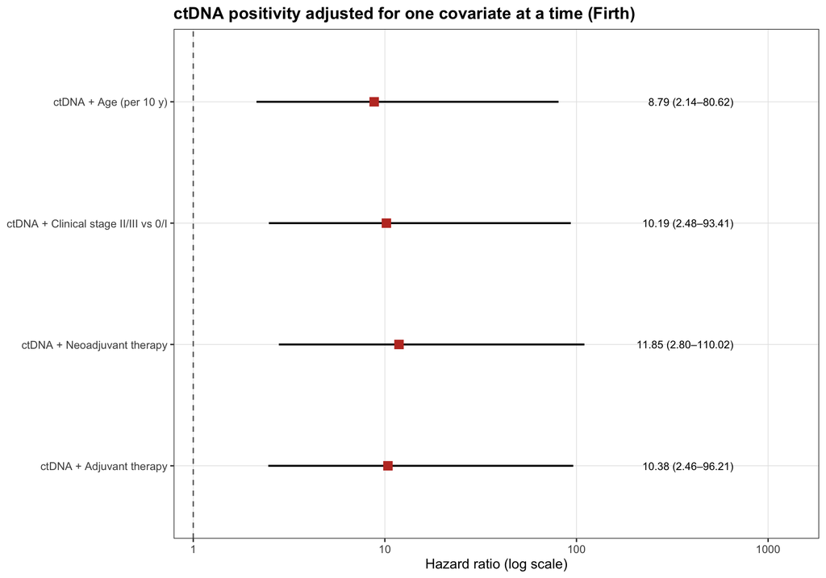

```r
write_csv(mva_tbl, file.path(out_dir, "R1_6_Firth_models.csv"))

forest_plot(biv |> filter(term == "groupPOSITIVE") |> mutate(label = model),
            "ctDNA positivity adjusted for one covariate at a time (Firth)")
```

```r
# **Publication-ready table: Firth-penalized Cox models (surveillance window, time 0 = surgery)**
term_lab <- c(groupPOSITIVE  = "ctDNA positive (vs. negative)",
              Age10          = "Age (per 10 years)",
              `cStageII/III` = "Clinical stage II/III (vs. 0/I)",
              NACTRUE        = "Neoadjuvant therapy (yes vs. no)",
              ACTTRUE        = "Adjuvant therapy (yes vs. no)")
model_lab <- c("ctDNA + Age (per 10 y)"                       = "Adjusted for age",
               "ctDNA + Clinical stage II/III vs 0/I"         = "Adjusted for clinical stage",
               "ctDNA + Neoadjuvant therapy"                  = "Adjusted for neoadjuvant therapy",
               "ctDNA + Adjuvant therapy"                     = "Adjusted for adjuvant therapy")
fmt_est <- function(x) ifelse(x >= 100, sprintf("%.0f", x), ifelse(x >= 10, sprintf("%.1f", x), sprintf("%.2f", x)))
fmt_pub_p <- function(p) ifelse(p < 0.001, "<0.001", sprintf("%.3f", p))

n_pts <- nrow(d_surv); n_ev <- sum(d_surv$event)

firth_pub <- mva_tbl |>
  mutate(Variable = coalesce(unname(term_lab[term]), term),
         Section  = case_when(grepl("^Univariable", model) ~ "Univariable models",
                              grepl("^ctDNA \\+", model)   ~ "ctDNA status adjusted for one covariate at a time",
                              TRUE                          ~ "Full model (all covariates; shown for completeness)"),
         Section  = factor(Section, levels = c("Univariable models",
                                               "ctDNA status adjusted for one covariate at a time",
                                               "Full model (all covariates; shown for completeness)")),
         Model    = case_when(grepl("^Univariable", model) ~ "Unadjusted",
                              grepl("^ctDNA \\+", model)   ~ coalesce(unname(model_lab[model]), model),
                              TRUE                          ~ "Mutually adjusted"),
         EPV      = case_when(grepl("^Univariable", model) ~ n_ev / 1,
                              grepl("^ctDNA \\+", model)   ~ n_ev / 2,
                              TRUE                          ~ n_ev / 5),
         `HR (95% CI)` = sprintf("%s (%s–%s)", fmt_est(HR), fmt_est(lower), fmt_est(upper)),
         P = fmt_pub_p(p),
         is_ctdna = term == "groupPOSITIVE",
         is_full  = !grepl("^Univariable|^ctDNA \\+", model)) |>
  arrange(Section) |>
  group_by(model) |>
  mutate(Model = ifelse(row_number() == 1, Model, ""),
         EPV   = ifelse(row_number() == 1, sprintf("%.1f", EPV), "")) |>
  ungroup()

gt_firth <- firth_pub |>
  select(Section, Model, Variable, `HR (95% CI)`, P, EPV, p, is_ctdna, is_full) |>
  gt(groupname_col = "Section") |>
  tab_header(
    title    = md("**Firth penalized-likelihood Cox regression for recurrence-free survival**"),
    subtitle = md(sprintf("Post-definitive treatment surveillance cohort (n = %d patients; %d events); time 0 = date of surgery",
                          n_pts, n_ev))) |>
  cols_label(Model = "Model", Variable = "Variable", P = md("*P*"), EPV = "Events per variable") |>
  cols_hide(c(p, is_ctdna, is_full)) |>
  cols_align("left",   columns = c(Model, Variable)) |>
  cols_align("center", columns = c(`HR (95% CI)`, P, EPV)) |>
  tab_style(style = list(cell_fill(color = "#FDF2F0"), cell_text(weight = "bold")),
            locations = cells_body(columns = c(Variable, `HR (95% CI)`), rows = is_ctdna)) |>
  tab_style(style = cell_text(weight = "bold"),
            locations = cells_body(columns = P, rows = p < 0.05)) |>
  tab_style(style = list(cell_fill(color = "#EEF3FB"), cell_text(weight = "bold", color = "#1F4E9C")),
            locations = cells_row_groups()) |>
  tab_style(style = cell_text(style = "italic", color = "grey40"),
            locations = cells_body(rows = is_full)) |>
  tab_source_note(md(paste0(
    "HR, hazard ratio; CI, profile-likelihood confidence interval. Hazard ratios were estimated with Firth's ",
    "penalized-likelihood Cox regression (R package coxphf). ctDNA status was defined in the post-definitive ",
    "treatment surveillance window. Bold *P* values are < 0.05. Given the small number of events, these models ",
    "are exploratory; the full model (events per variable 2.8) is shown for completeness and is not interpreted."))) |>
  tab_options(table.font.names = c("Arial", "Helvetica", "sans-serif"),
              table.font.size = px(13),
              heading.align = "left",
              heading.title.font.size = px(16),
              heading.subtitle.font.size = px(13),
              column_labels.font.weight = "bold",
              column_labels.border.top.color = "black",
              column_labels.border.bottom.color = "black",
              table.border.top.color = "white",
              table.border.bottom.color = "black",
              row_group.border.top.color = "grey70",
              row_group.border.bottom.color = "grey70",
              data_row.padding = px(4),
              source_notes.font.size = px(11))
gt_firth
```

**Firth penalized-likelihood Cox regression for recurrence-free survival**

Post-definitive treatment surveillance cohort (n = 31 patients; 14 events); time 0 = date of surgery

| Model | Variable | HR (95% CI) | *P* | Events per variable |
| --- | --- | --- | --- | --- |
| Univariable models |  |  |  |  |
| Unadjusted | ctDNA positive (vs. negative) | 10.3 (2.51–94.5) | <0.001 | 14.0 |
| Unadjusted | Age (per 10 years) | 1.95 (1.06–3.94) | 0.031 | 14.0 |
| Unadjusted | Clinical stage II/III (vs. 0/I) | 1.21 (0.36–6.23) | 0.782 | 14.0 |
| Unadjusted | Neoadjuvant therapy (yes vs. no) | 1.19 (0.29–3.73) | 0.785 | 14.0 |
| Unadjusted | Adjuvant therapy (yes vs. no) | 1.47 (0.48–5.85) | 0.518 | 14.0 |
| ctDNA status adjusted for one covariate at a time |  |  |  |  |
| Adjusted for age | ctDNA positive (vs. negative) | 8.79 (2.14–80.6) | 0.001 | 7.0 |
|  | Age (per 10 years) | 1.92 (0.93–4.49) | 0.080 |  |
| Adjusted for clinical stage | ctDNA positive (vs. negative) | 10.2 (2.48–93.4) | <0.001 | 7.0 |
|  | Clinical stage II/III (vs. 0/I) | 1.01 (0.29–5.26) | 0.988 |  |
| Adjusted for neoadjuvant therapy | ctDNA positive (vs. negative) | 11.9 (2.80–110) | <0.001 | 7.0 |
|  | Neoadjuvant therapy (yes vs. no) | 0.58 (0.12–2.00) | 0.415 |  |
| Adjusted for adjuvant therapy | ctDNA positive (vs. negative) | 10.4 (2.46–96.2) | <0.001 | 7.0 |
|  | Adjuvant therapy (yes vs. no) | 0.90 (0.29–3.64) | 0.871 |  |
| Full model (all covariates; shown for completeness) |  |  |  |  |
| Mutually adjusted | ctDNA positive (vs. negative) | 10.8 (2.28–110) | 0.002 | 2.8 |
|  | Age (per 10 years) | 2.09 (0.99–4.89) | 0.054 |  |
|  | Clinical stage II/III (vs. 0/I) | 2.46 (0.52–16.1) | 0.266 |  |
|  | Neoadjuvant therapy (yes vs. no) | 0.61 (0.11–2.41) | 0.498 |  |
|  | Adjuvant therapy (yes vs. no) | 0.67 (0.15–3.35) | 0.602 |  |

HR, hazard ratio; CI, profile-likelihood confidence interval. Hazard ratios were estimated with Firth’s penalized-likelihood Cox regression (R package coxphf). ctDNA status was defined in the post-definitive treatment surveillance window. Bold *P* values are < 0.05. Given the small number of events, these models are exploratory; the full model (events per variable 2.8) is shown for completeness and is not interpreted.

```r
# Exports: Word (editable), HTML, and PNG (PNG needs the webshot2 package + Chrome)
gtsave(gt_firth, file.path(out_dir, "Table_Firth_models_surveillance.docx"))
gtsave(gt_firth, file.path(out_dir, "Table_Firth_models_surveillance.html"))
tryCatch(gtsave(gt_firth, file.path(out_dir, "Table_Firth_models_surveillance.png"), expand = 20, zoom = 3),
         error = function(e) message("PNG export skipped (install webshot2): ", conditionMessage(e)))
```

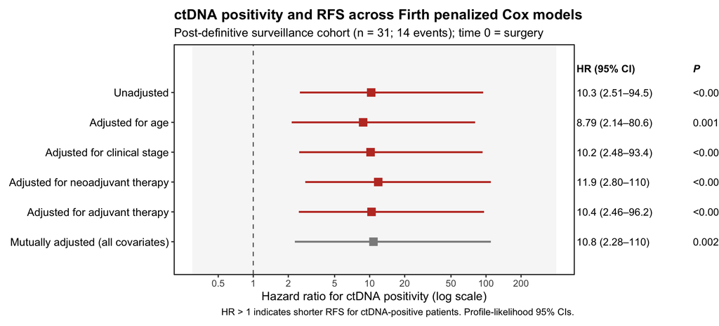

```r
# **Figure version: ctDNA hazard ratio across Firth models, with estimates printed alongside**
forest_df <- firth_pub |>
  filter(is_ctdna) |>
  mutate(label = case_when(Section == "Univariable models" ~ "Unadjusted",
                           grepl("one covariate", Section) ~ Model,
                           TRUE ~ "Mutually adjusted (all covariates)"),
         label = factor(label, levels = rev(label)),
         kind  = ifelse(label == "Mutually adjusted (all covariates)", "Full model", "Primary / one-covariate"))

x_txt1 <- 600; x_txt2 <- 6000
p_forest_firth <- ggplot(forest_df, aes(x = HR, y = label)) +
  annotate("rect", xmin = 0.3, xmax = 400, ymin = -Inf, ymax = Inf, fill = "grey97") +
  geom_vline(xintercept = 1, linetype = "dashed", colour = "grey40") +
  geom_linerange(aes(xmin = lower, xmax = upper, colour = kind), linewidth = 1) +
  geom_point(aes(colour = kind), shape = 15, size = 4) +
  geom_text(aes(x = x_txt1, label = `HR (95% CI)`), hjust = 0, size = 4) +
  geom_text(aes(x = x_txt2, label = P), hjust = 0, size = 4) +
  annotate("text", x = x_txt1, y = nrow(forest_df) + 0.8, label = "HR (95% CI)", hjust = 0, fontface = "bold", size = 4) +
  annotate("text", x = x_txt2, y = nrow(forest_df) + 0.8, label = "P", hjust = 0, fontface = "bold.italic", size = 4) +
  scale_x_log10(breaks = c(0.5, 1, 2, 5, 10, 20, 50, 100, 200), labels = c("0.5", "1", "2", "5", "10", "20", "50", "100", "200")) +
  scale_colour_manual(values = c("Primary / one-covariate" = pal_ctdna[2], "Full model" = "grey55"), guide = "none") +
  coord_cartesian(xlim = c(0.3, 400), ylim = c(0.5, nrow(forest_df) + 1), clip = "off") +
  labs(x = "Hazard ratio for ctDNA positivity (log scale)", y = NULL,
       title = "ctDNA positivity and RFS across Firth penalized Cox models",
       subtitle = sprintf("Post-definitive surveillance cohort (n = %d; %d events); time 0 = surgery", n_pts, n_ev),
       caption = "HR > 1 indicates shorter RFS for ctDNA-positive patients. Profile-likelihood 95% CIs.") +
  theme_utuc(13) +
  theme(plot.margin = margin(10, 160, 10, 10), panel.grid.major.y = element_blank(),
        axis.text.y = element_text(size = 12, colour = "black"))
p_forest_firth
```

```r
save_fig(p_forest_firth, "Fig_Firth_ctDNA_forest_surveillance", w = 11, h = 5)
```

```r
# **Time-dependent ctDNA with Firth penalization, adjusted for one covariate at a time**
dt_cov <- dt_model |> left_join(select(d_surv, Patient.ID, Age10, cStage, NAC, ACT), by = "Patient.ID")
td_biv <- imap_dfr(covs, function(lbl, cv) {
  f <- coxphf(as.formula(paste("Surv(tstart, tstop, dfs_event) ~ biomarker_status +", cv)), data = dt_cov)
  firth_tidy(f, paste("Time-dependent ctDNA +", lbl))
})
show_tbl(bind_rows(firth_tidy(fit_td_f, "Time-dependent ctDNA (univariable)"), td_biv),
         "Firth-penalized time-dependent Cox models")
```

| term | HR | lower | upper | p | method | model |
| --- | --- | --- | --- | --- | --- | --- |
| biomarker_statusPOSITIVE | 29.882 | 6.785 | 282.798 | 0 | Firth penalized Cox (profile-likelihood CI) | Time-dependent ctDNA (univariable) |
| biomarker_statusPOSITIVE | 28.672 | 6.295 | 274.671 | 0 | Firth penalized Cox (profile-likelihood CI) | Time-dependent ctDNA + Age (per 10 y) |
| Age10 | 0.986 | 0.483 | 2.144 | 0.97 | Firth penalized Cox (profile-likelihood CI) | Time-dependent ctDNA + Age (per 10 y) |
| biomarker_statusPOSITIVE | 28.699 | 6.581 | 270.455 | 0 | Firth penalized Cox (profile-likelihood CI) | Time-dependent ctDNA + Clinical stage II/III vs 0/I |
| cStageII/III | 1.329 | 0.37 | 7.019 | 0.685 | Firth penalized Cox (profile-likelihood CI) | Time-dependent ctDNA + Clinical stage II/III vs 0/I |
| biomarker_statusPOSITIVE | 33.191 | 7.211 | 320.687 | 0 | Firth penalized Cox (profile-likelihood CI) | Time-dependent ctDNA + Neoadjuvant therapy |
| NACTRUE | 0.76 | 0.187 | 2.421 | 0.657 | Firth penalized Cox (profile-likelihood CI) | Time-dependent ctDNA + Neoadjuvant therapy |
| biomarker_statusPOSITIVE | 28.306 | 6.26 | 270.689 | 0 | Firth penalized Cox (profile-likelihood CI) | Time-dependent ctDNA + Adjuvant therapy |
| ACTTRUE | 1.151 | 0.338 | 4.911 | 0.831 | Firth penalized Cox (profile-likelihood CI) | Time-dependent ctDNA + Adjuvant therapy |

## 9.4 Pre-operative ctDNA (Reviewer 2, comment 3)

```r
# **Patients with a pre-operative plasma sample**
pre <- op |> filter(is_ct, date.diff <= 0) |>
  transmute(PatientName, preop_day = date.diff, preop_window = ctDNA.Window,
            preop_status = ifelse(Event_type == "ctDNA_pos", "POSITIVE", "NEGATIVE"), preop_MTM = MTM.mL)
post <- op |> filter(is_ct, date.diff > 0) |>
  arrange(PatientName, date.diff) |> group_by(PatientName) |>
  summarise(first_postop_day = first(date.diff), first_postop_status = ifelse(first(Event_type) == "ctDNA_pos", "POSITIVE", "NEGATIVE"),
            first_postop_MTM = first(MTM.mL), any_postop_pos = any(Event_type == "ctDNA_pos"), .groups = "drop")
preop_tbl <- pre |> left_join(post, by = "PatientName") |>
  left_join(select(cohort, Patient.ID, Stage, NAC, ctDNA.Baseline, ctDNA.MRD, RFS.Event, RFS.months), by = c("PatientName" = "Patient.ID")) |>
  mutate(pattern = case_when(preop_status == "POSITIVE" & first_postop_status == "POSITIVE" ~ "Persistent",
                             preop_status == "POSITIVE" & first_postop_status == "NEGATIVE" ~ "Cleared post-op",
                             preop_status == "NEGATIVE" & first_postop_status == "POSITIVE" ~ "Neg → Pos",
                             TRUE ~ "Negative pre & post"))
show_tbl(preop_tbl, "Pre-operative vs first post-operative ctDNA")
```

| PatientName | preop_day | preop_window | preop_status | preop_MTM | first_postop_day | first_postop_status | first_postop_MTM | any_postop_pos | Stage | NAC | ctDNA.Baseline | ctDNA.MRD | RFS.Event | RFS.months | pattern |
| --- | --- | --- | --- | --- | --- | --- | --- | --- | --- | --- | --- | --- | --- | --- | --- |
| UTUC-035 | -39 | Baseline | POSITIVE | 1.59 | 22 | POSITIVE | 0.09 | True | II | False | POSITIVE | POSITIVE | True | 7.491 | Persistent |
| UTUC-060 | -15 | Baseline | NEGATIVE | 0 | 43 | NEGATIVE | 0 | True | II | False | NEGATIVE | NEGATIVE | True | 10.645 | Negative pre &amp; post |
| UTUC-021 | -16 | Baseline | NEGATIVE | 0 | 30 | POSITIVE | 0.06 | True | III | False | NEGATIVE | POSITIVE | False | 16.756 | Neg → Pos |
| UTUC-022 | -1 | Baseline | POSITIVE | 0.63 | 25 | NEGATIVE | 0 | True | 0/I | False | POSITIVE | POSITIVE | True | 10.119 | Cleared post-op |

```r
# Clinical-tab baseline calls without a matching OP pre-operative sample
cohort |> filter(!is.na(ctDNA.Baseline), !Patient.ID %in% pre$PatientName) |>
  select(Patient.ID, ctDNA.Baseline, ctDNA.MRD, ctDNA.timing) |> show_tbl("QC — baseline call in clinical tab but no pre-op sample in OP tab")
```

| Patient.ID | ctDNA.Baseline | ctDNA.MRD | ctDNA.timing |
| --- | --- | --- | --- |
| UTUC-041 | POSITIVE | NEGATIVE | 65 |

## 9.5 Time origin and event definition (Reviewer 2, comment 5)

```r
# **Time origin and event definition for each RFS analysis**
tibble(
  Analysis = c("Fig 2A (early post-operative MRD window)", "Fig 2B (post-definitive window, time-fixed)",
               "Time-dependent Cox (serial post-definitive ctDNA)", "Lead time (Fig 3C)"),
  `Time 0` = c("Date of the early post-operative ctDNA draw (2–16 weeks, before any adjuvant therapy)",
               "Date of surgery",
               "Start of post-definitive window (end of adjuvant therapy, or surgery if none); delayed entry at first draw",
               "First post-operative ctDNA-positive result"),
  Event = c(rep("First recurrence at any site (intravesical, locoregional, distant); censored at last follow-up", 3),
            "Radiographic recurrence"),
  `Patients / events` = c(sprintf("%d / %d", nrow(d_mrd), sum(d_mrd$event)),
                          sprintf("%d / %d", nrow(d_surv), sum(d_surv$event)),
                          sprintf("%d / %d", n_distinct(dt_model$Patient.ID), sum(dt_model$dfs_event)),
                          sprintf("%d recurrences", nrow(ltd)))
) |> show_tbl("Time origin and event definition per analysis")
```

| Analysis | Time 0 | Event | Patients / events |
| --- | --- | --- | --- |
| Fig 2A (early post-operative MRD window) | Date of the early post-operative ctDNA draw (2–16 weeks, before any adjuvant therapy) | First recurrence at any site (intravesical, locoregional, distant); censored at last follow-up | 28 / 14 |
| Fig 2B (post-definitive window, time-fixed) | Date of surgery | First recurrence at any site (intravesical, locoregional, distant); censored at last follow-up | 31 / 14 |
| Time-dependent Cox (serial post-definitive ctDNA) | Start of post-definitive window (end of adjuvant therapy, or surgery if none); delayed entry at first draw | First recurrence at any site (intravesical, locoregional, distant); censored at last follow-up | 30 / 13 |
| Lead time (Fig 3C) | First post-operative ctDNA-positive result | Radiographic recurrence | 16 recurrences |

```r
cat("Deaths without prior recurrence in the final cohort:", sum(cohort$OS.Event & !cohort$RFS.Event), "\n")
```

```
## Deaths without prior recurrence in the final cohort: 0
```